# Clustering Census Data

Aidan Redmond

6/21/2021

# Census Segmentation

## Read data and prep

First we want to read in the census data file which has been downloaded from [the CSO](https://www.cso.ie/en/census/census2016reports/census2016smallareapopulationstatistics/).

This report has been run using the Electoral Division boundaries but different levels of granularity are available from Small Area to provinces.

```r
#read in data and join together
data_ED = read.csv(file="SAPS2016_ED3409.csv",stringsAsFactors = FALSE)
```

| GUID | GEOGID | GEOGDESC | T1_1AGE0M | T1_1AGE1M | T1_1AGE2M | T1_1AGE3M | T1_1AGE4M | T1_1AGE5M | T1_1AGE6M | T1_1AGE7M | T1_1AGE8M | T1_1AGE9M | T1_1AGE10M | T1_1AGE11M | T1_1AGE12M | T1_1AGE13M | T1_1AGE14M | T1_1AGE15M | T1_1AGE16M | T1_1AGE17M | T1_1AGE18M | T1_1AGE19M | T1_1AGE20_24M | T1_1AGE25_29M | T1_1AGE30_34M | T1_1AGE35_39M | T1_1AGE40_44M | T1_1AGE45_49M | T1_1AGE50_54M | … |
| --- | --- | --- | --- | --- | --- | --- | --- | --- | --- | --- | --- | --- | --- | --- | --- | --- | --- | --- | --- | --- | --- | --- | --- | --- | --- | --- | --- | --- | --- | --- |
| 2AE19629185813A3E055000000000001 | ED3409_01001 | Carlow Urban | 21 | 27 | 16 | 24 | 35 | 25 | 30 | 16 | 21 | 14 | 13 | 23 | 23 | 17 | 29 | 20 | 25 | 14 | 31 | 39 | 259 | 245 | 212 | 175 | 167 | 145 | 151 | … |
| 2AE196291A5913A3E055000000000001 | ED3409_01002 | Graigue Urban | 6 | 5 | 9 | 9 | 7 | 10 | 7 | 10 | 9 | 3 | 9 | 7 | 14 | 9 | 7 | 6 | 7 | 8 | 6 | 10 | 40 | 111 | 69 | 36 | 38 | 36 | 36 | … |
| 2AE19629186413A3E055000000000001 | ED3409_01003 | Clonmore | 2 | 1 | 2 | 3 | 2 | 2 | 4 | 3 | 8 | 7 | 4 | 1 | 2 | 5 | 6 | 6 | 1 | 3 | 3 | 4 | 19 | 15 | 15 | 14 | 20 | 16 | 19 | … |
| 2AE19629187F13A3E055000000000001 | ED3409_01004 | Hacketstown | 9 | 15 | 8 | 4 | 15 | 6 | 10 | 11 | 13 | 7 | 12 | 10 | 12 | 9 | 11 | 10 | 10 | 8 | 6 | 5 | 34 | 31 | 39 | 41 | 45 | 28 | 33 | … |
| 2AE19629188713A3E055000000000001 | ED3409_01005 | Haroldstown | 2 | 1 | 2 | 2 | 3 | 2 | 0 | 1 | 2 | 1 | 4 | 2 | 1 | 1 | 1 | 3 | 6 | 3 | 4 | 1 | 4 | 7 | 6 | 5 | 13 | 13 | 12 | … |
| 2AE19629189713A3E055000000000001 | ED3409_01006 | Kineagh | 0 | 3 | 3 | 1 | 3 | 1 | 0 | 1 | 1 | 0 | 1 | 1 | 2 | 3 | 1 | 2 | 1 | 3 | 3 | 2 | 11 | 7 | 11 | 9 | 15 | 11 | 21 | … |

After reading in the data, we want to create some variables that we can use for the clustering. The column names in the data are coded to save space. A glossary is available which is included in the table below.

```r
#Upload the glossary
Glossary = read.csv(file="SAPS_2016_Glossary.csv",stringsAsFactors = FALSE)
```

| ï..Themes | Tables.Within.Themes | Column.Names | Description.of.Field | Equivalent.SAPS2011.Variable..if.name.changed. | Points.to.Note |
| --- | --- | --- | --- | --- | --- |
| Theme 1: Sex, Age and Marital Status | Table 1 | T1_1AGE0M | Age 0 - Males |  |  |
|  | Population aged 0 - 19 by sex and year of age, persons aged 20 years and over by sex and age group | T1_1AGE1M | Age 1 - Males |  |  |
|  |  | T1_1AGE2M | Age 2 - Males |  |  |
|  |  | T1_1AGE3M | Age 3 - Males |  |  |
|  |  | T1_1AGE4M | Age 4 - Males |  |  |
|  |  | T1_1AGE5M | Age 5 - Males |  |  |
|  |  | T1_1AGE6M | Age 6 - Males |  |  |
|  |  | T1_1AGE7M | Age 7 - Males |  |  |
|  |  | T1_1AGE8M | Age 8 - Males |  |  |
|  |  | T1_1AGE9M | Age 9 - Males |  |  |
|  |  | T1_1AGE10M | Age 10 - Males |  |  |
|  |  | T1_1AGE11M | Age 11 - Males |  |  |
|  |  | T1_1AGE12M | Age 12 - Males |  |  |
|  |  | T1_1AGE13M | Age 13 - Males |  |  |
|  |  | T1_1AGE14M | Age 14 - Males |  |  |
|  |  | T1_1AGE15M | Age 15 - Males |  |  |
|  |  | T1_1AGE16M | Age 16 - Males |  |  |
|  |  | T1_1AGE17M | Age 17 - Males |  |  |
|  |  | T1_1AGE18M | Age 18 - Males |  |  |
|  |  | T1_1AGE19M | Age 19 - Males |  |  |
|  |  | T1_1AGE20_24M | Age 20 - 24 - Males |  |  |
|  |  | T1_1AGE25_29M | Age 25 - 29 - Males |  |  |
|  |  | T1_1AGE30_34M | Age 30 - 34 - Males |  |  |
|  |  | T1_1AGE35_39M | Age 35 - 39 - Males |  |  |
|  |  | T1_1AGE40_44M | Age 40 - 44 - Males |  |  |
|  |  | T1_1AGE45_49M | Age 45 - 49 - Males |  |  |
|  |  | T1_1AGE50_54M | Age 50 - 54 - Males |  |  |
|  |  | T1_1AGE55_59M | Age 55 - 59 - Males |  |  |
|  |  | T1_1AGE60_64M | Age 60 - 64 - Males |  |  |
|  |  | T1_1AGE65_69M | Age 65 - 69 - Males |  |  |

[output cut: 769 more lines]

I have selected some population data and created some new features of interest from them which might tell us about socio demographics of the population. Information about the size of the household, percentage renting etc has been used

```r
#People per household
data_ED = data_ED %>%
    mutate(People_HH = (T1_1AGETT/T5_1T_H))
#Vacant Houses
data_ED = data_ED %>%
    mutate(VacantHouse = T6_8_OVD/T6_8_T)
#Employment
data_ED = data_ED %>%
    mutate(Pct_Unemployed = T8_1_ULGUPJT/T8_1_TT)
#Renting
data_ED = data_ED %>%
    mutate(Pct_Rented = T6_3_RPLH/T6_3_TH)
#Cars per Household
data_ED = data_ED %>%
    mutate(Cars = (T15_1_1C + T15_1_2C*2 + T15_1_3C*3 + T15_1_GE4C*4))
data_ED = data_ED %>%
    mutate(Cars_per_HH = Cars/T5_1T_H)

rownames(data_ED) = data_ED$GEOGID

#only keep new variables
data_ED = data_ED %>%
    select(People_HH,VacantHouse,Pct_Unemployed,Pct_Rented,Cars_per_HH)
```

|  | People_HH | VacantHouse | Pct_Unemployed | Pct_Rented | Cars_per_HH |
| --- | --- | --- | --- | --- | --- |
| ED3409_01001 | 2.273181 | 0.1296066 | 0.1244888 | 0.3107232 | 0.7512463 |
| ED3409_01002 | 2.303279 | 0.1566265 | 0.1107383 | 0.1412151 | 0.8229508 |
| ED3409_01003 | 2.843243 | 0.1165919 | 0.0508475 | 0.0489130 | 1.6648649 |
| ED3409_01004 | 2.806533 | 0.0997831 | 0.1474057 | 0.0810127 | 1.4346734 |
| ED3409_01005 | 2.960000 | 0.0900901 | 0.1063830 | 0.0200000 | 1.6000000 |
| ED3409_01006 | 2.858333 | 0.1231884 | 0.0739437 | 0.0583333 | 1.7416667 |

All of the variables that I have created are numeric so there is no one-hot encoding to be carried out on factors but this is a step that you could carry out here. I did however scale and centre the data so that all the features are on a consistent basis (because the metrics are different across each one).

```r
#scale and centre the data prior to clustering
data_ED_scale = (scale(data_ED, center = TRUE, scale = TRUE))
```

|  | People_HH | VacantHouse | Pct_Unemployed | Pct_Rented | Cars_per_HH |
| --- | --- | --- | --- | --- | --- |
| ED3409_01001 | -1.8301945 | 0.3311974 | 1.9836402 | 2.0020204 | -2.3800612 |
| ED3409_01002 | -1.7257155 | 0.8025786 | 1.5317049 | 0.3265837 | -2.1490849 |
| ED3409_01003 | 0.1486458 | 0.1041467 | -0.4367156 | -0.5857402 | 0.5629062 |
| ED3409_01004 | 0.0212135 | -0.1890957 | 2.7368462 | -0.2684640 | -0.1785915 |
| ED3409_01005 | 0.5539397 | -0.3581969 | 1.3885608 | -0.8715199 | 0.3539622 |
| ED3409_01006 | 0.2010275 | 0.2192270 | 0.3223834 | -0.4926290 | 0.8103018 |

## K-Means

### Methodology

First we are going to look at some K-Means clustering on the census variables that we have created.

The first thing we need to do is to estimate how many clusters we need to build. To do this we run the k-means algorithm across an array of different values of k and make an estimate based on the Within Cluster Sum of Squares WSS.

We try to choose k where there is an elbow in the plot or where adding another cluster does not improve WSS much

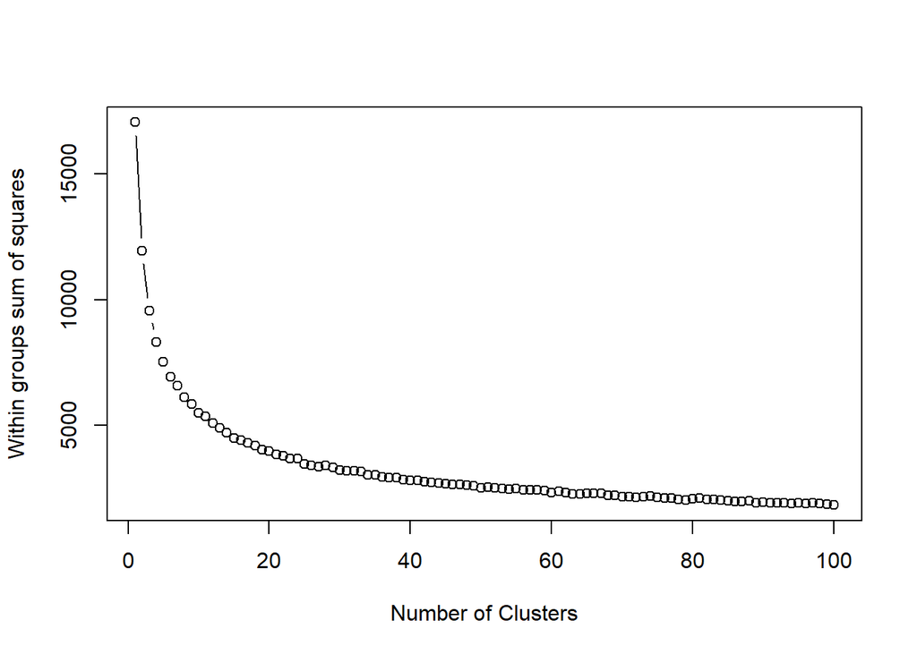

```r
#cluster using kmeans - Scaled Data
wss <- (nrow(data_ED_scale)-1)*sum(apply(data_ED_scale,2,var))
for (i in 2:100) wss[i] <- sum(kmeans(data_ED_scale,
                                      centers=i,iter.max=30)$withinss)
plot(1:100, wss, type="b", xlab="Number of Clusters",
     ylab="Within groups sum of squares")
```

It looks as though 6 clusters might be appropriate and so we re-run the k-means algorithm with 6 clusters selected.

```r
k=6

KM_Cluster_scale = kmeans(data_ED_scale,centers=k,iter.max=30)
```

### Cluster 1

#### People_HH

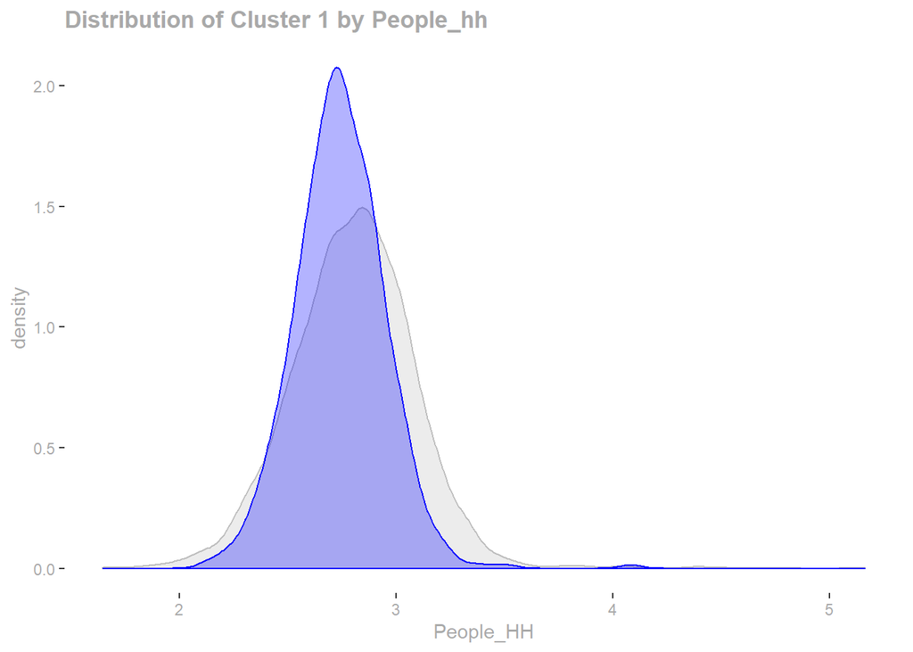

#### VacantHouse

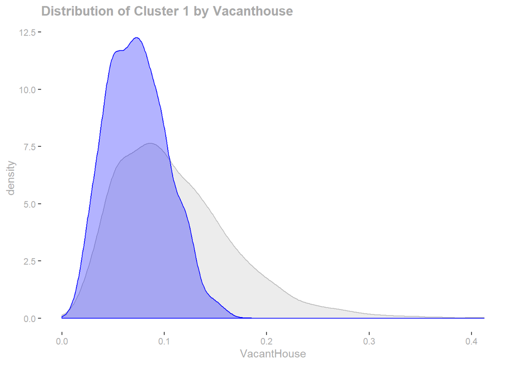

#### Pct_Unemployed

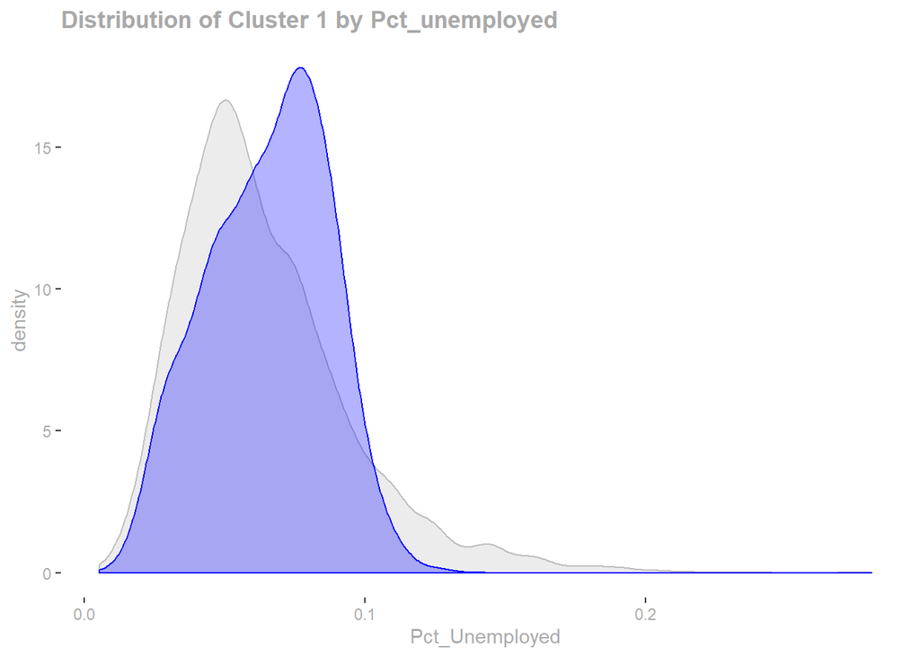

#### Pct_Rented

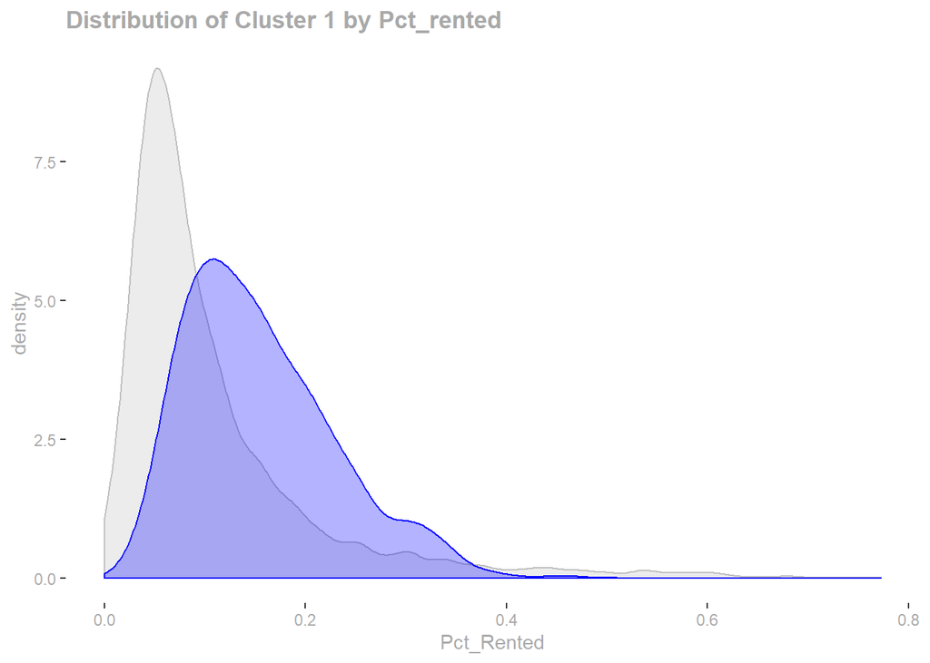

#### Cars_per_HH

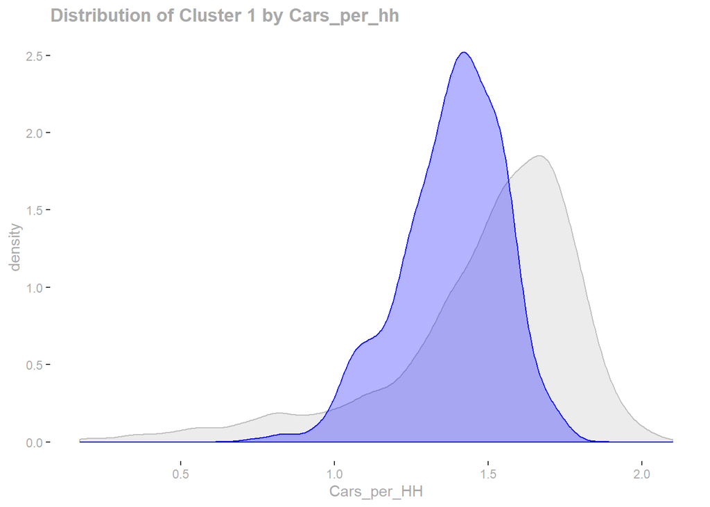

### Cluster 2

#### People_HH

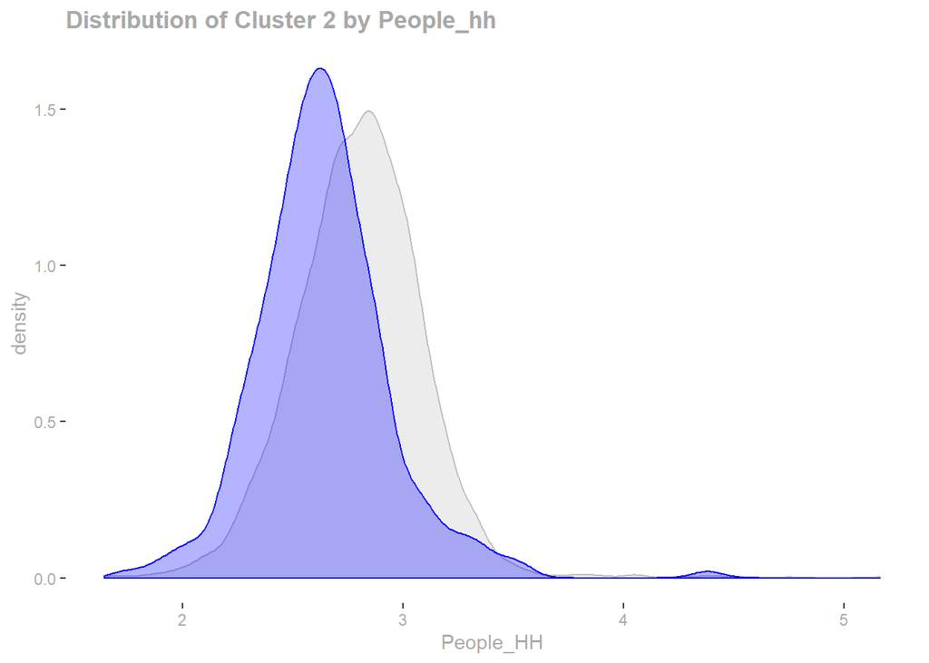

#### VacantHouse

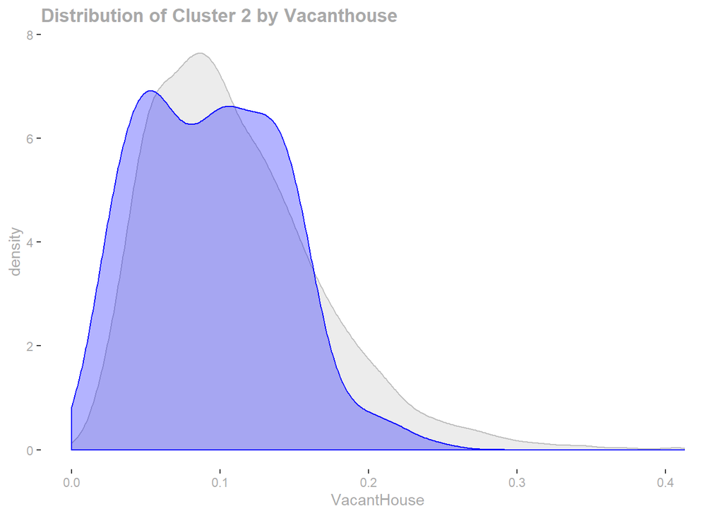

#### Pct_Unemployed

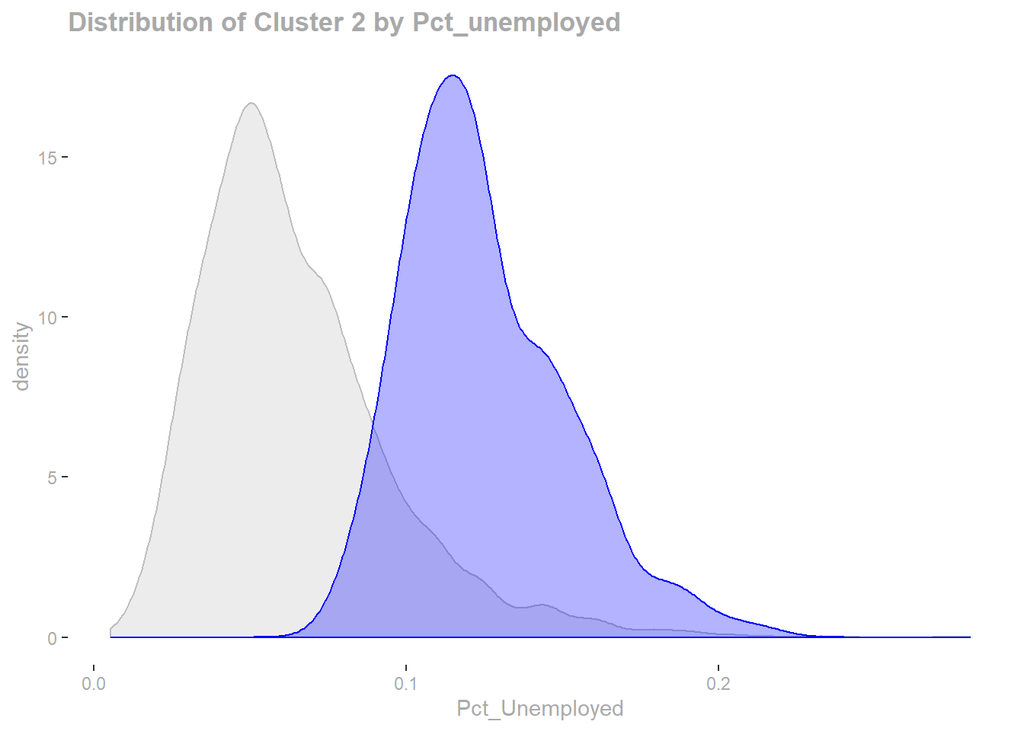

#### Pct_Rented

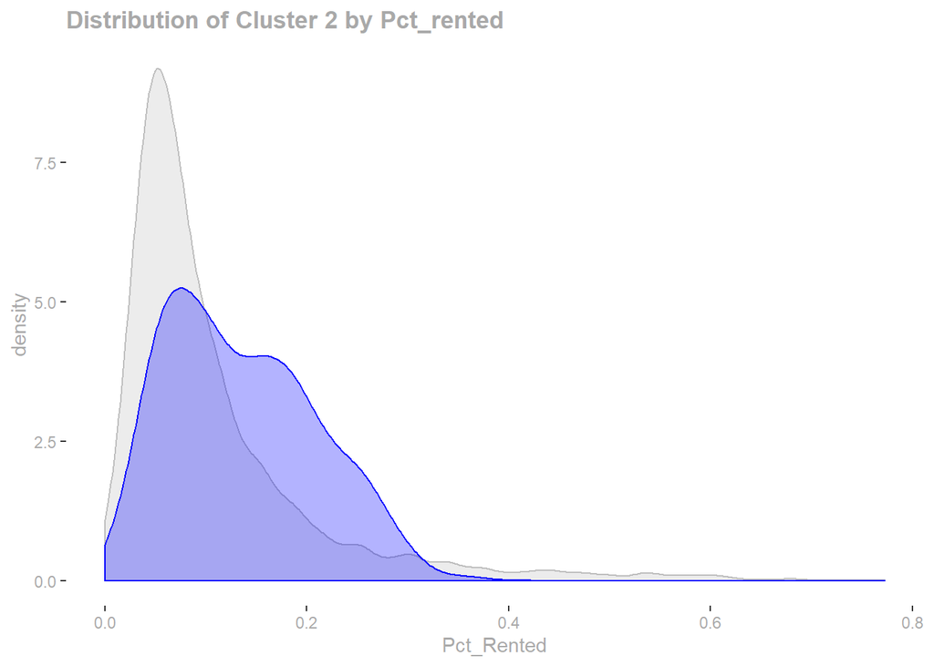

#### Cars_per_HH

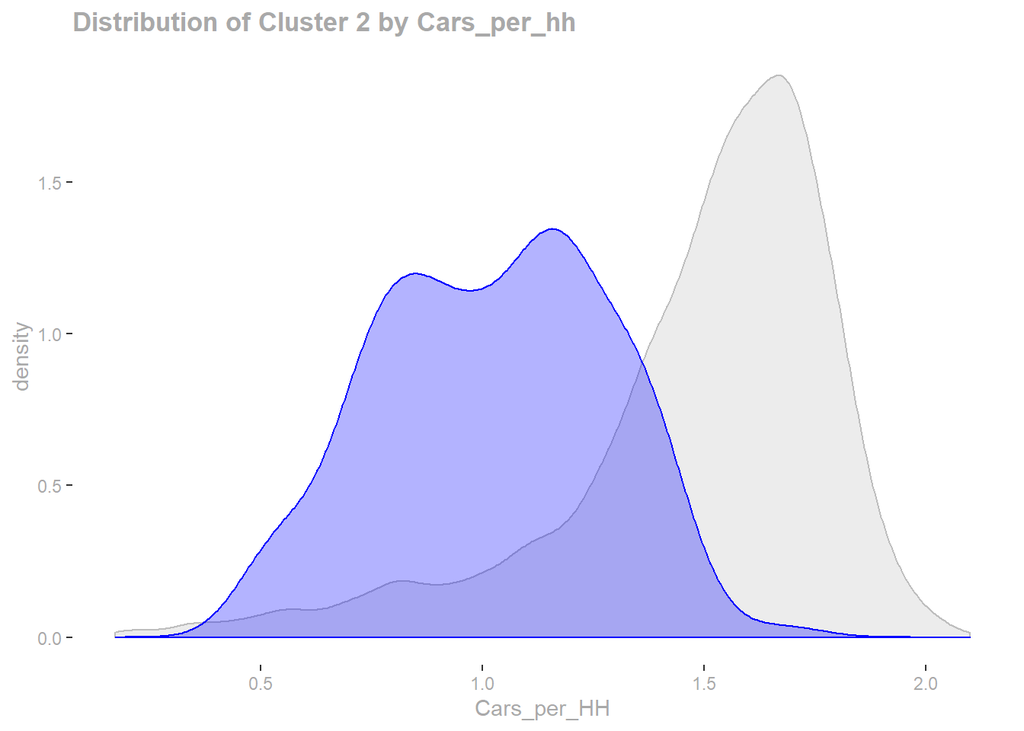

### Cluster 3

#### People_HH

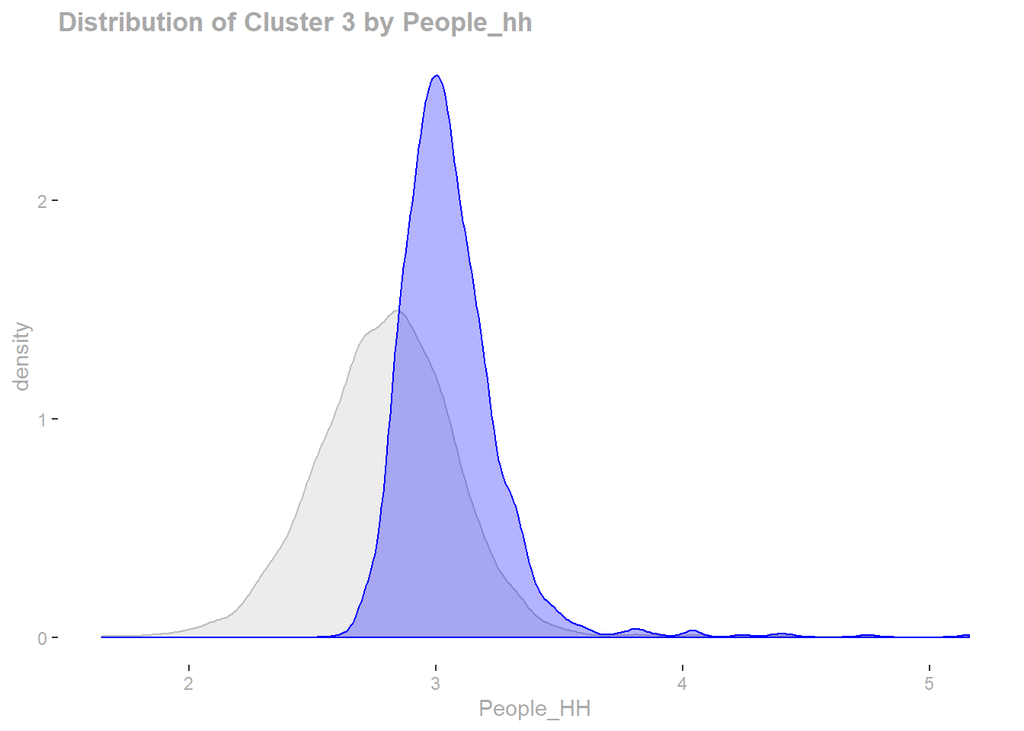

#### VacantHouse

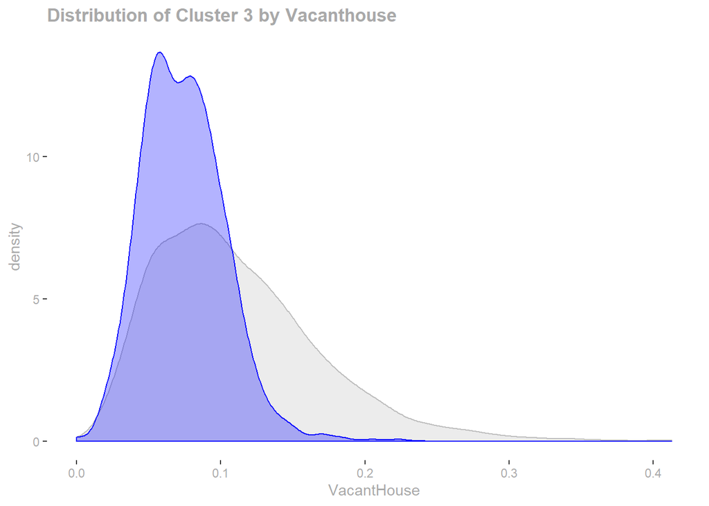

#### Pct_Unemployed

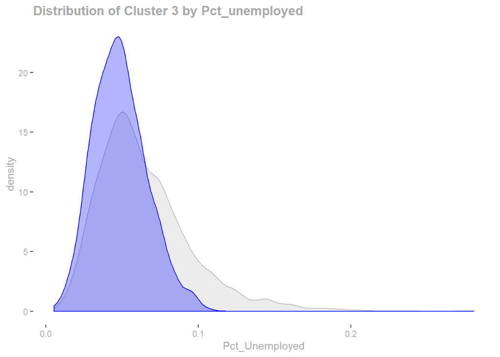

#### Pct_Rented

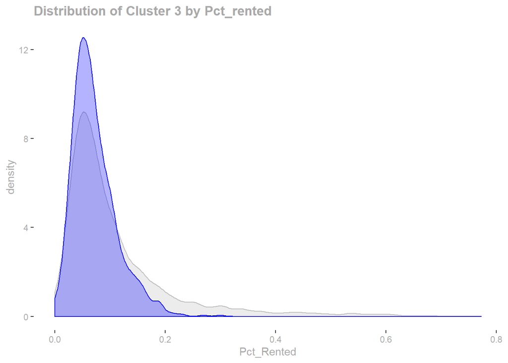

#### Cars_per_HH

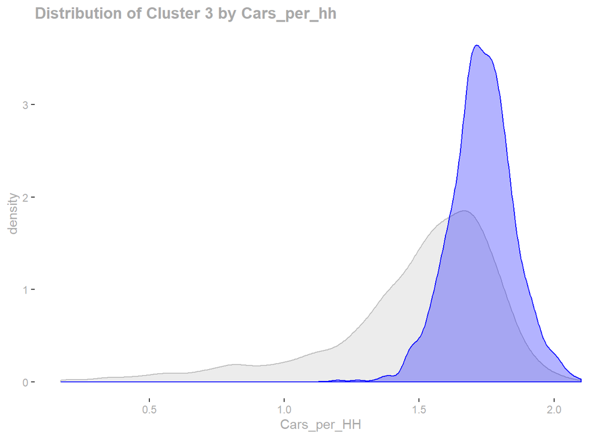

### Cluster 4

#### People_HH

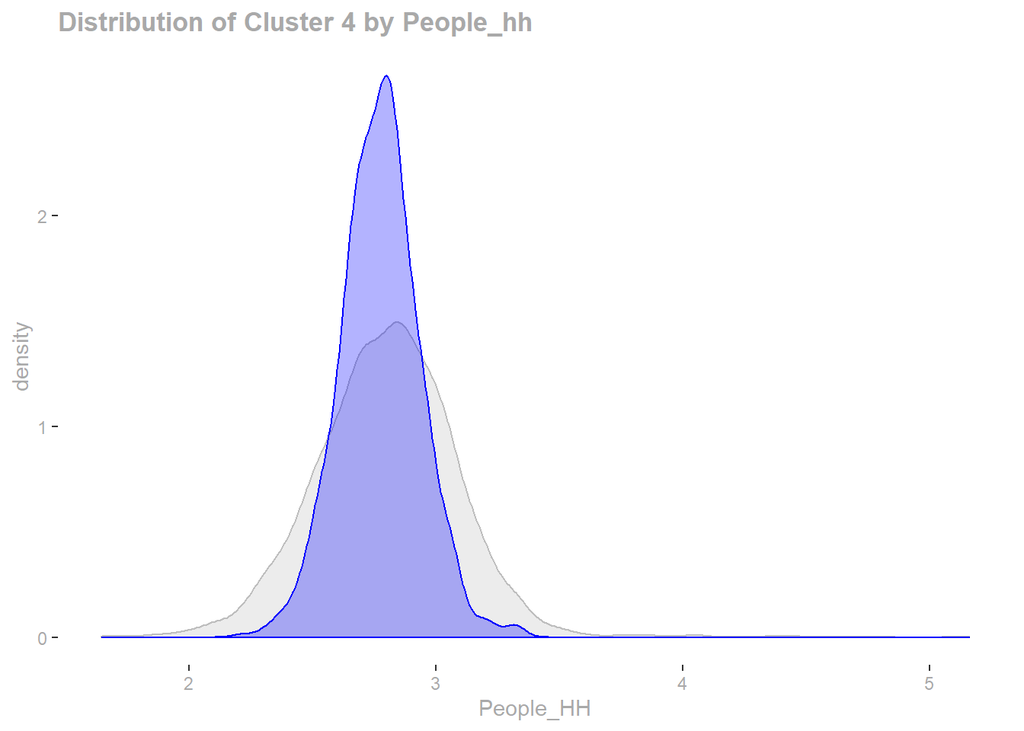

#### VacantHouse

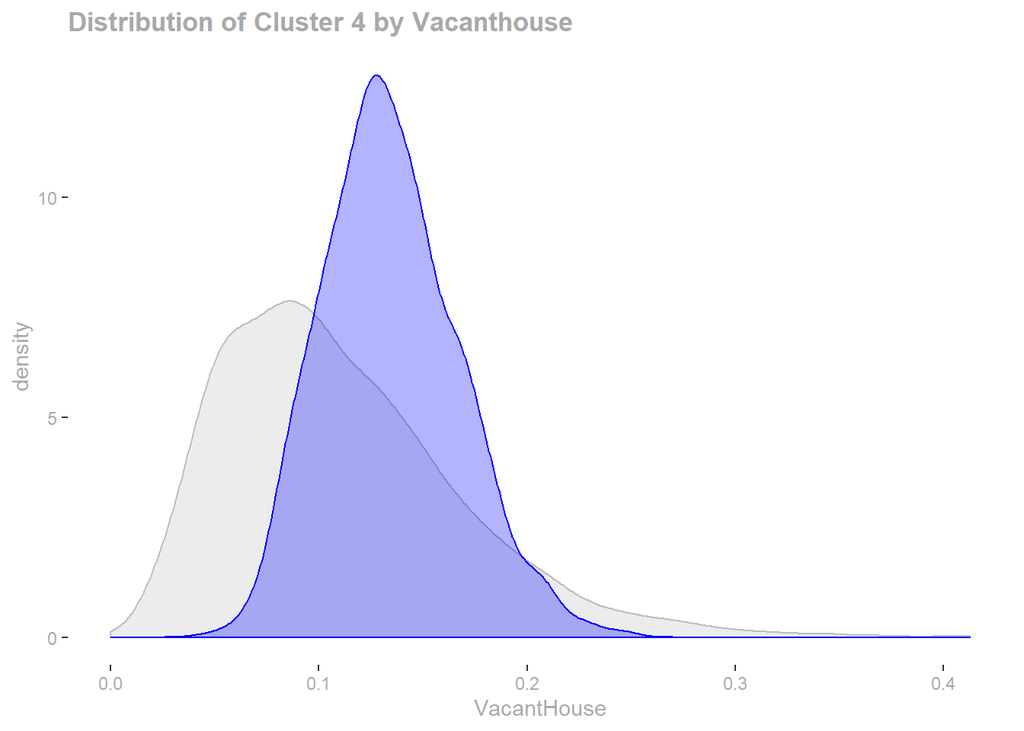

#### Pct_Unemployed

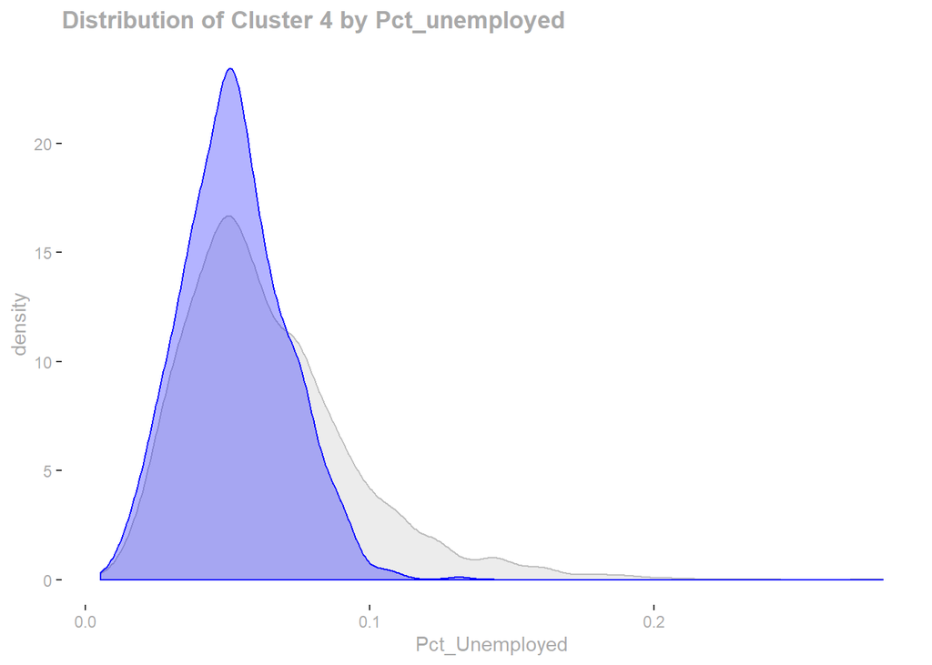

#### Pct_Rented

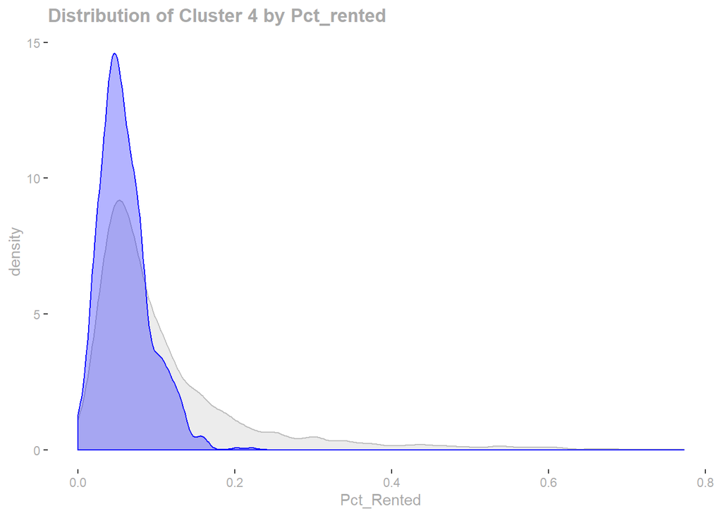

#### Cars_per_HH

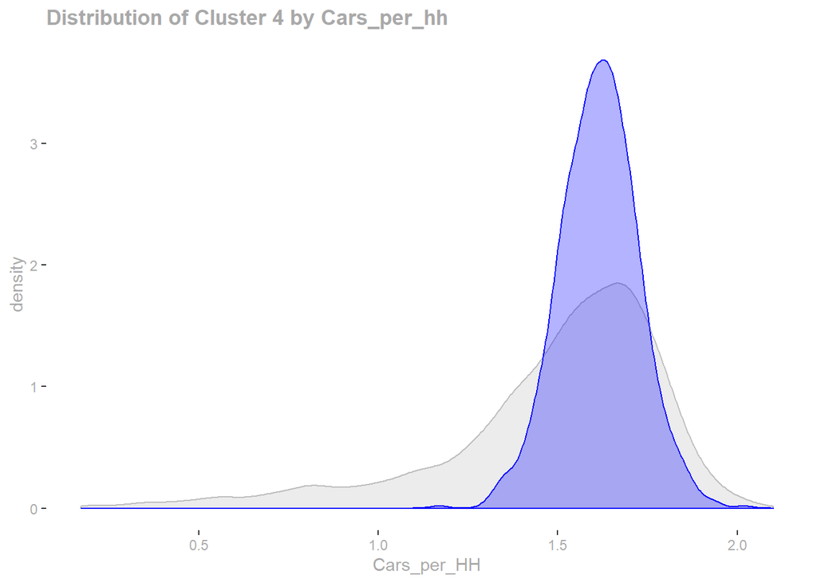

### Cluster 5

#### People_HH

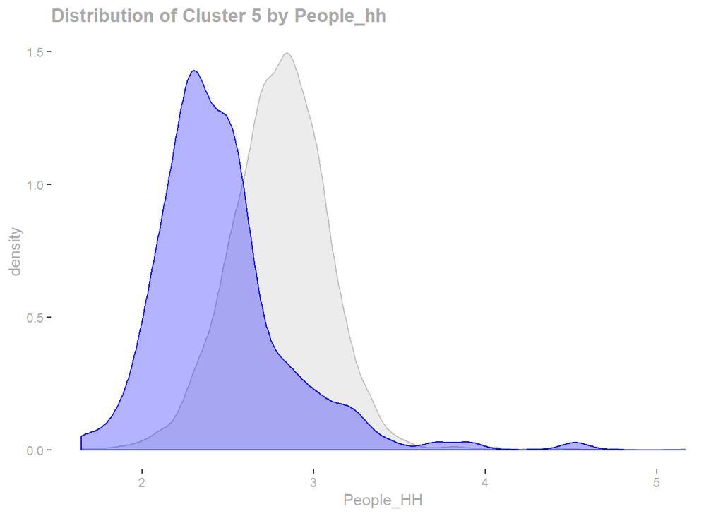

#### VacantHouse

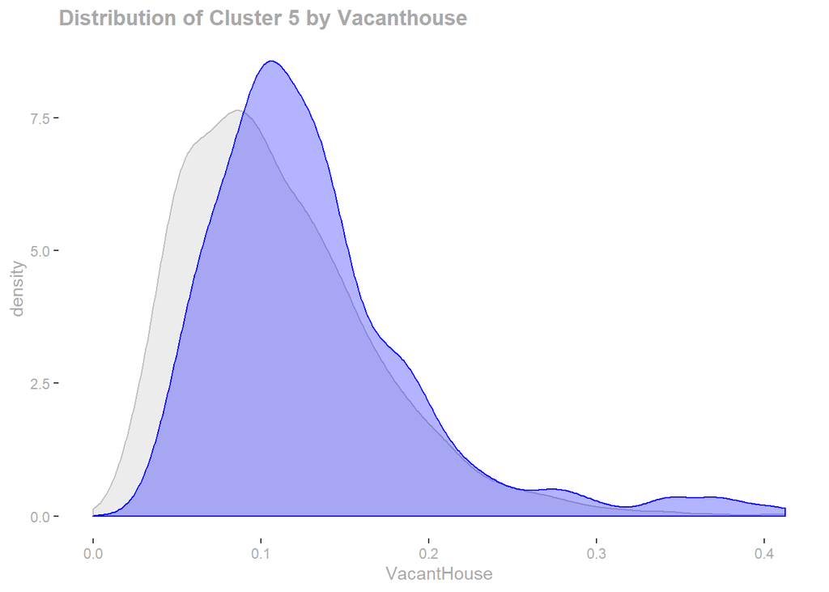

#### Pct_Unemployed

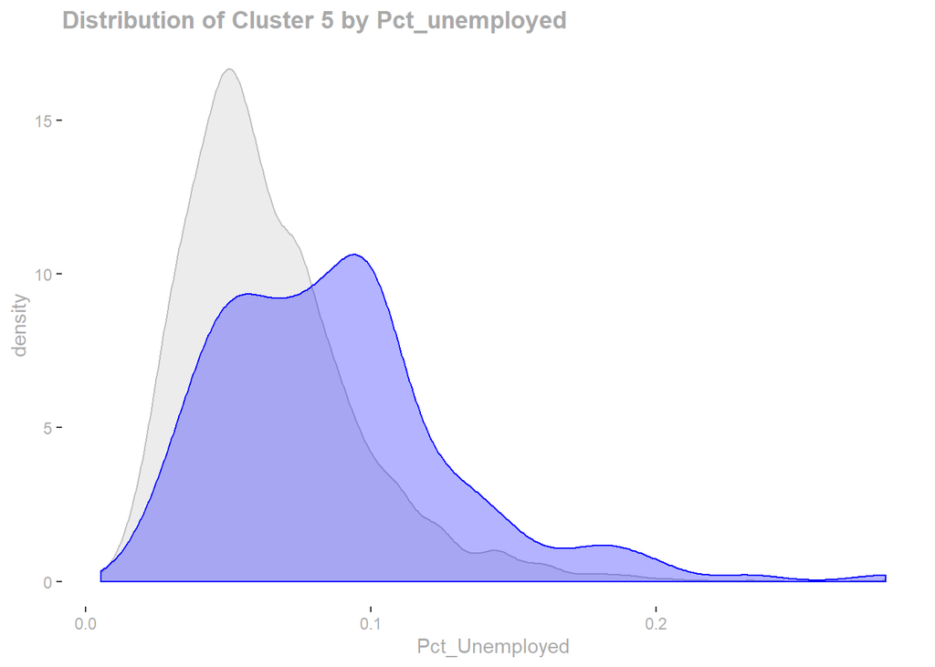

#### Pct_Rented

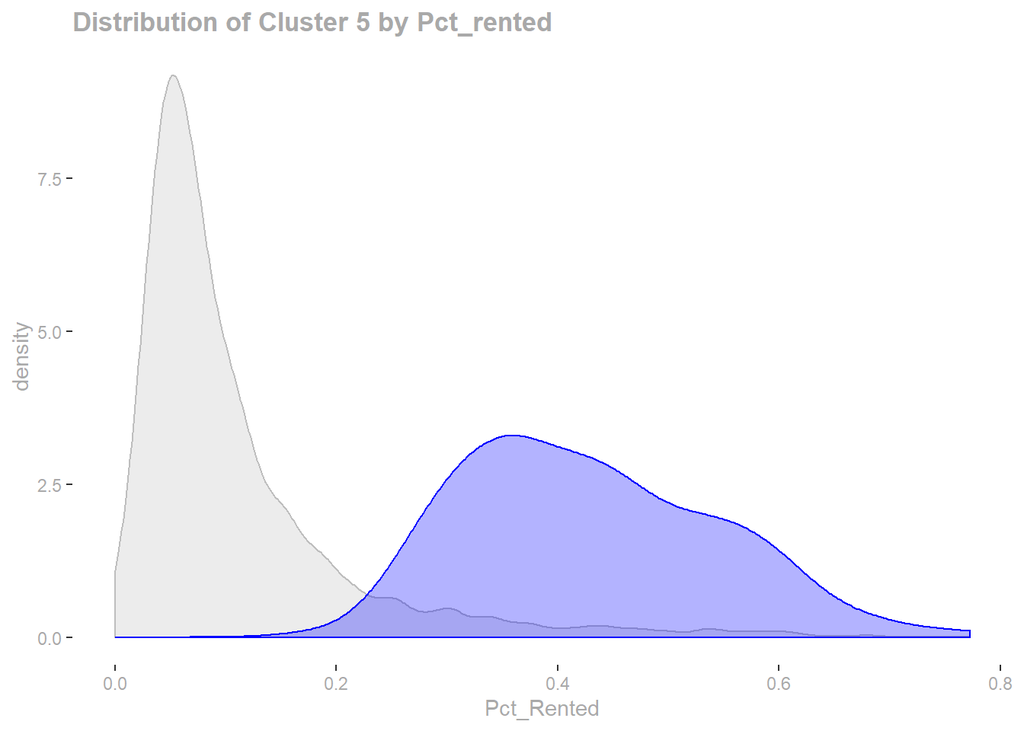

#### Cars_per_HH

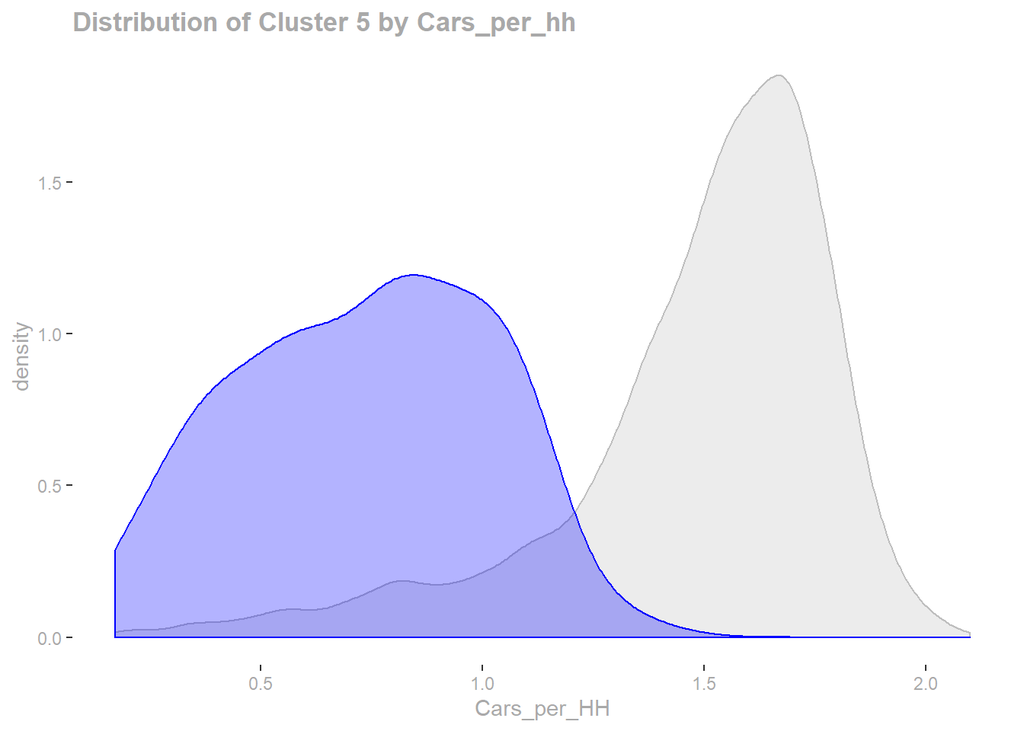

### Cluster 6

#### People_HH

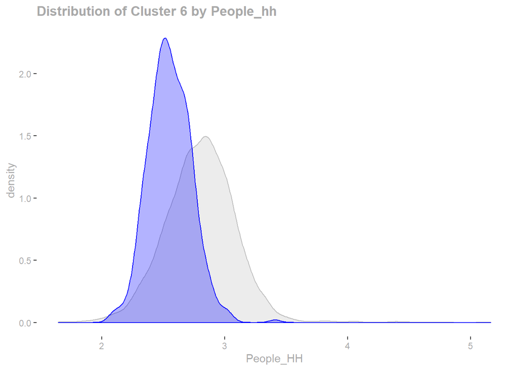

#### VacantHouse

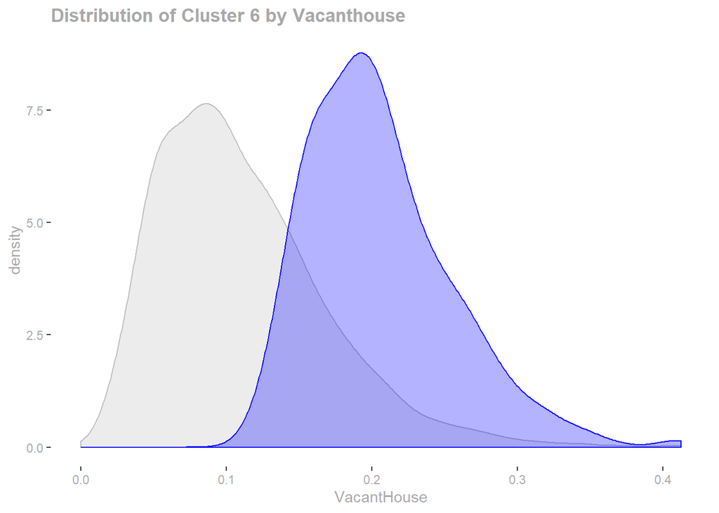

#### Pct_Unemployed

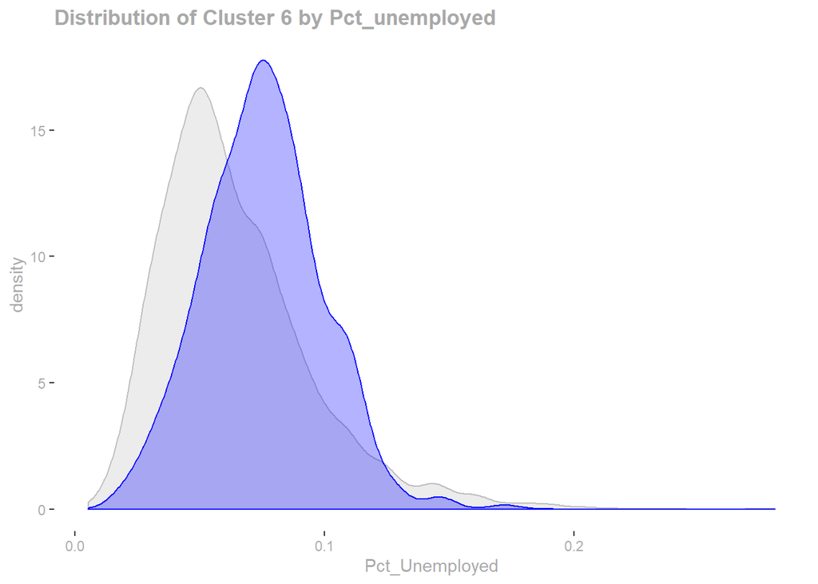

#### Pct_Rented

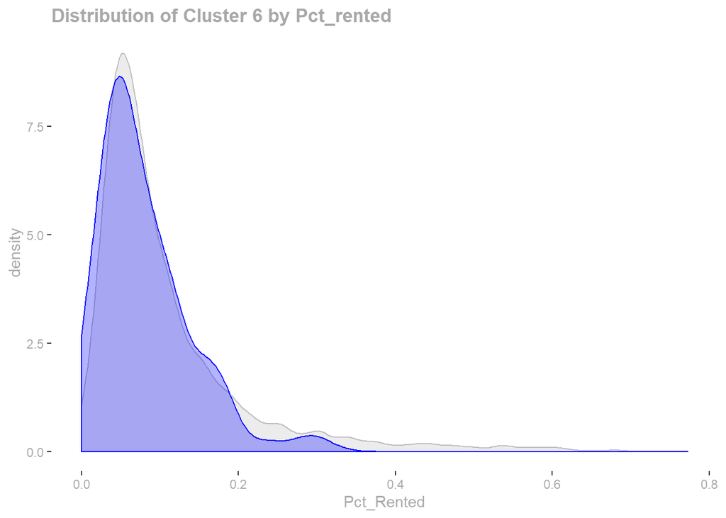

#### Cars_per_HH

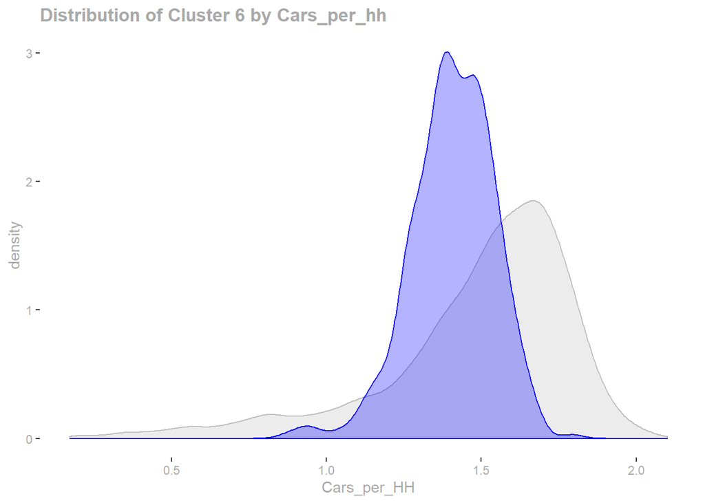

## Partioning Around Medoids PAM

### Methodology

After looking at K-Means, we look at an alternative methodology, K-medoids or PAM. Again the first thing to do is to select the ideal number of clusters.

In this instance we will use the Average Silhouette to choose the optimal number of clusters, with the largest silhouette indicating the best.

```r
# Determine number of clusters
asw <- numeric(20)

## Note that "k=1" won't work!
for (k in 2:20)
  asw[k] <- pam(data_ED, k) $ silinfo $ avg.width
k.best <- which.max(asw)
cat("silhouette-optimal number of clusters:", k.best, "\n")
```

```
## silhouette-optimal number of clusters: 2
```

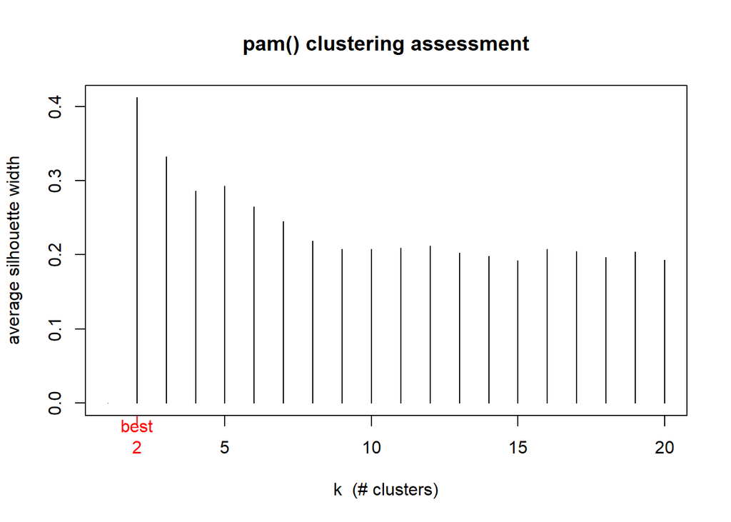

```r
plot(1:20, asw, type= "h", main = "pam() clustering assessment",
     xlab= "k  (# clusters)", ylab = "average silhouette width")
axis(1, k.best, paste("best",k.best,sep="\n"), col = "red", col.axis = "red")
```

The graph indicates that 2 clusters are most appropriate so again we run the algorithm with this input

```r
pam = pam(data_ED_scale, k.best)
```

### Cluster 1

#### People_HH

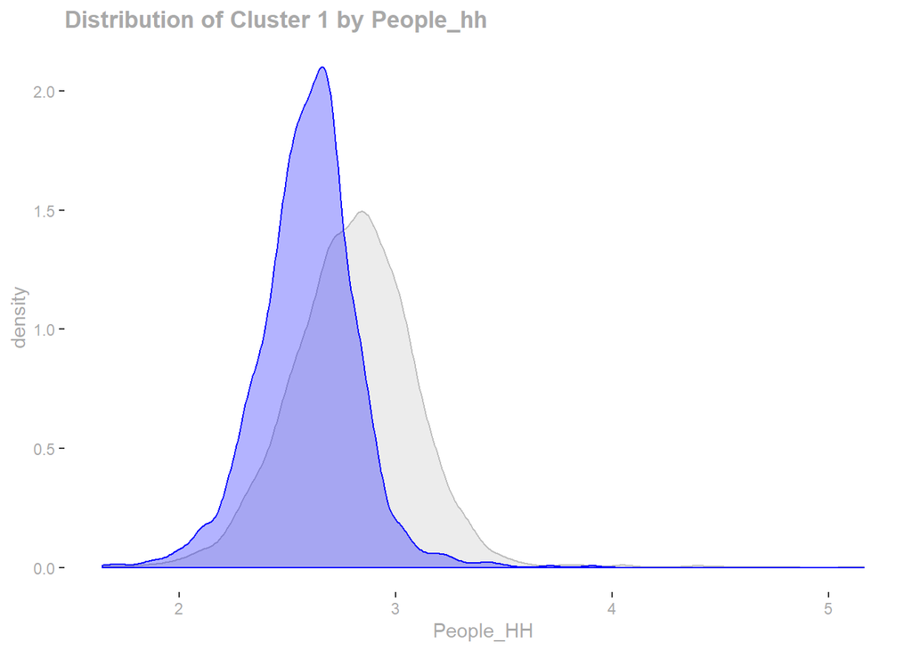

#### VacantHouse

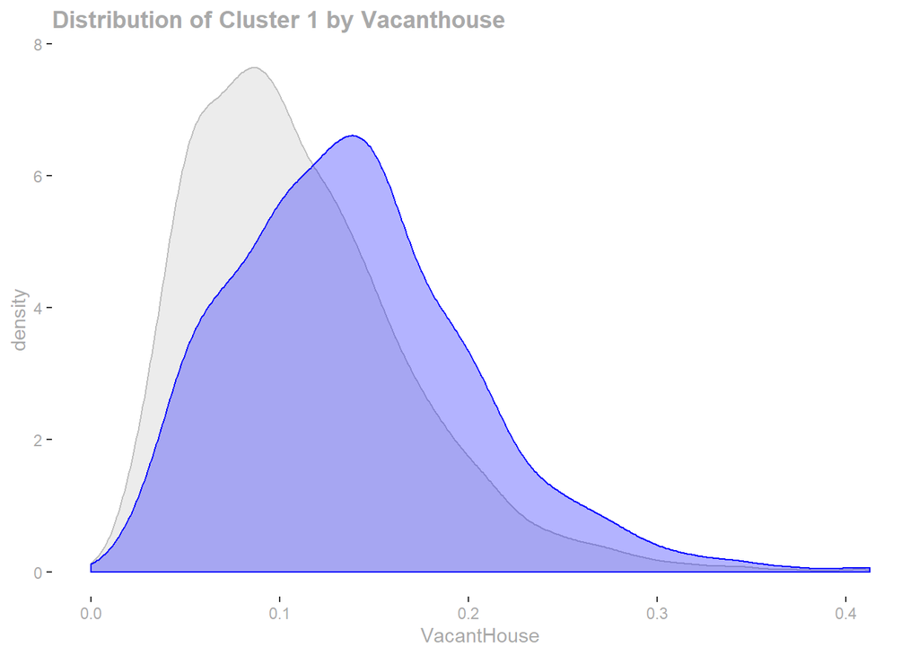

#### Pct_Unemployed

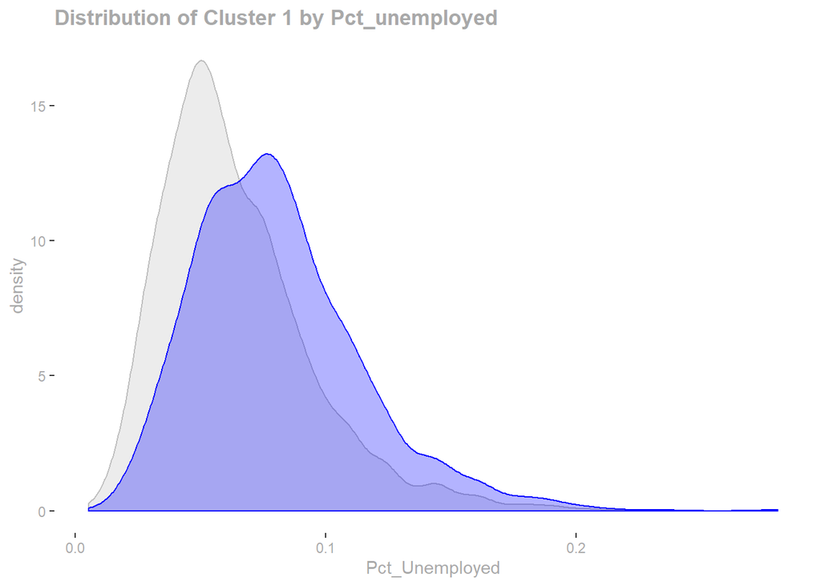

#### Pct_Rented

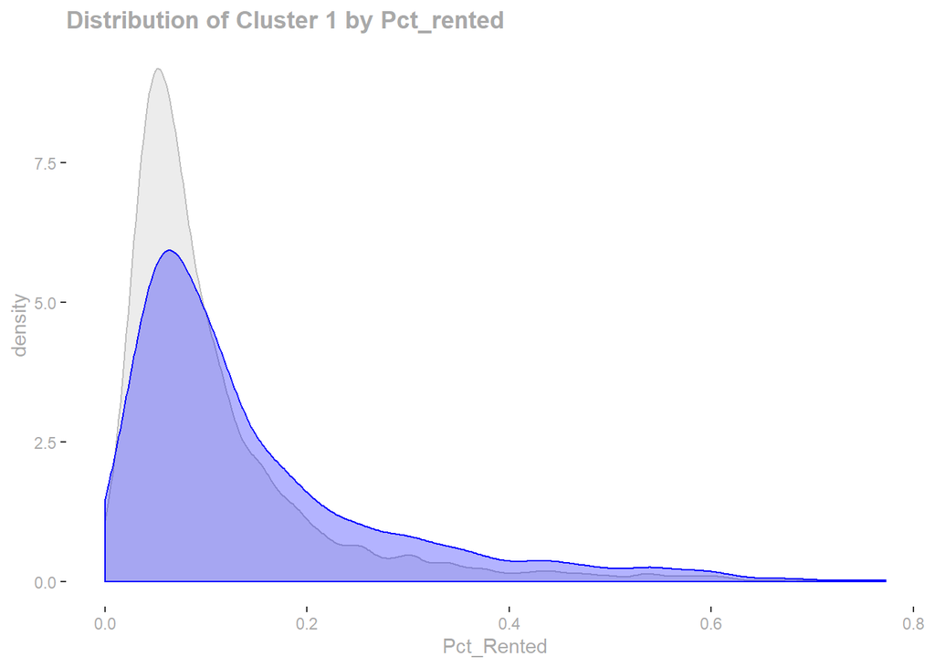

#### Cars_per_HH

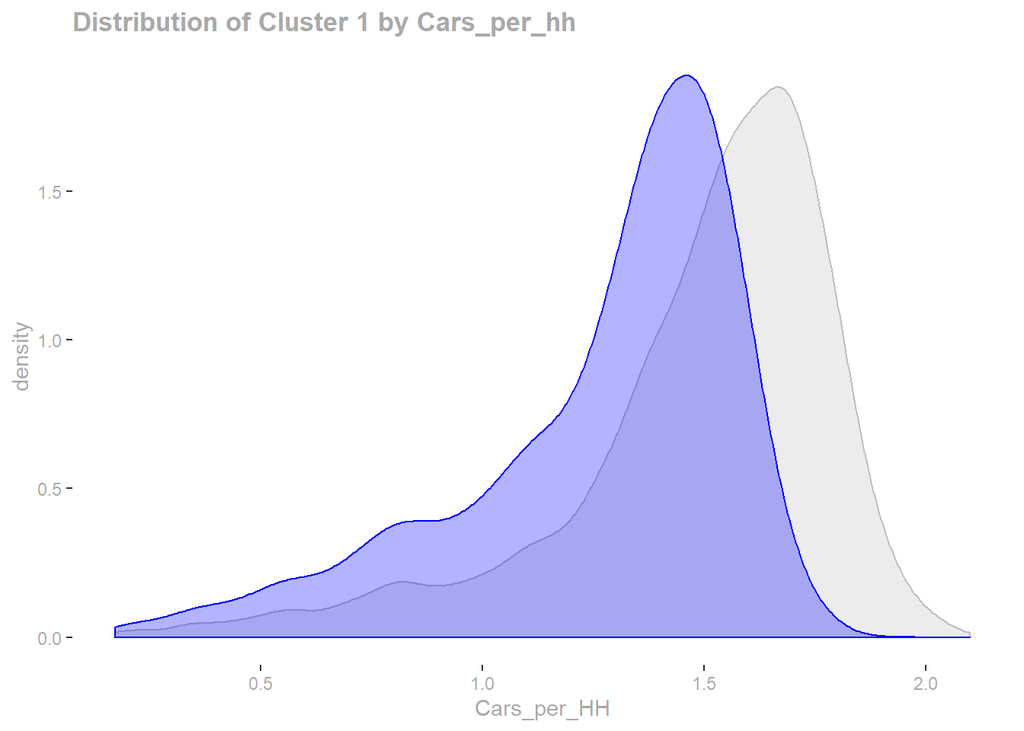

### Cluster 2

#### People_HH

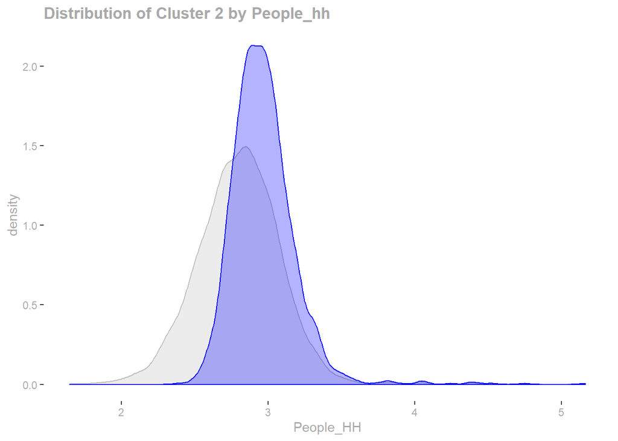

#### VacantHouse

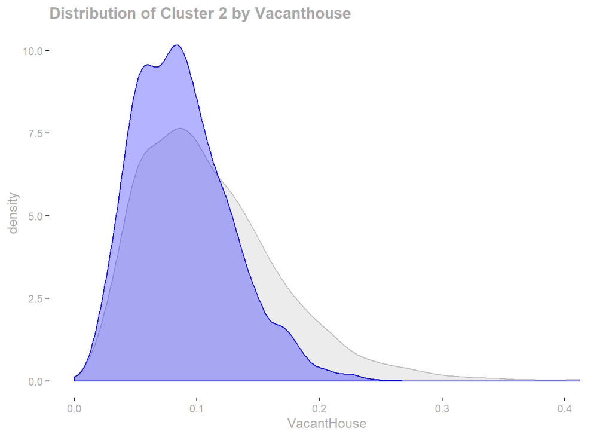

#### Pct_Unemployed

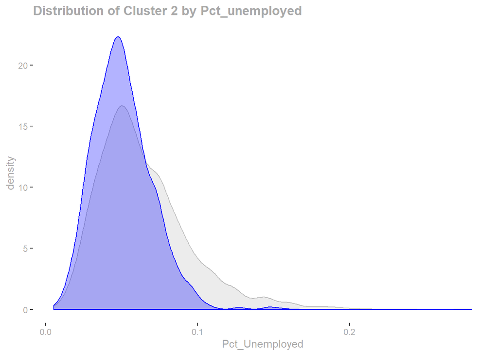

#### Pct_Rented

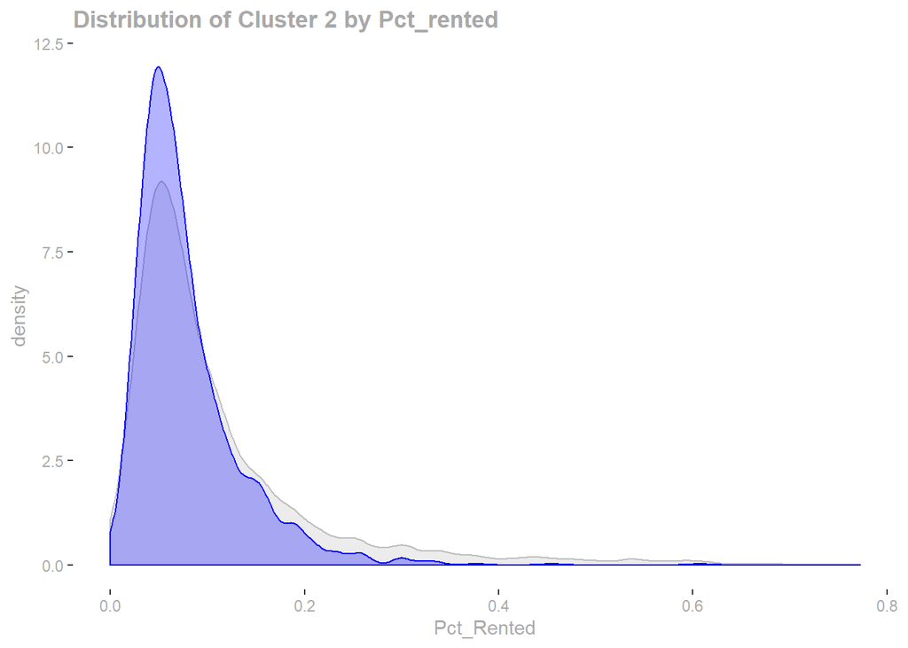

#### Cars_per_HH

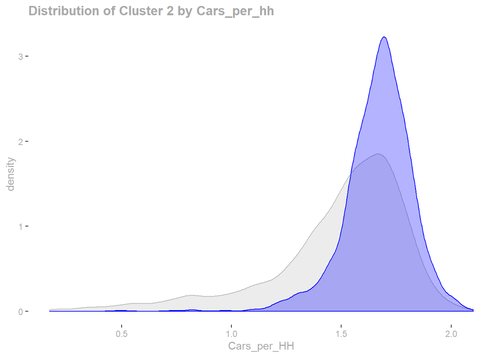

## Model Based Clustering

### Methodology

Finally we will look at Model Based Clustering on the census data. In this instance the mclust algorithm chooses the most appropriate model form and the most appropriate numbers of clusters.

```r
Model_Clust = Mclust(data_ED_scale)
summary(Model_Clust)
```

```
## ----------------------------------------------------
## Gaussian finite mixture model fitted by EM algorithm
## ----------------------------------------------------
##
## Mclust VVV (ellipsoidal, varying volume, shape, and orientation) model with 6
## components:
##
##  log-likelihood    n  df       BIC       ICL
##       -17767.38 3409 125 -36551.53 -38433.85
##
## Clustering table:
##    1    2    3    4    5    6
##  370  165  695  286 1273  620
```

The plot below shows the BIC for each model type and number of clusters.

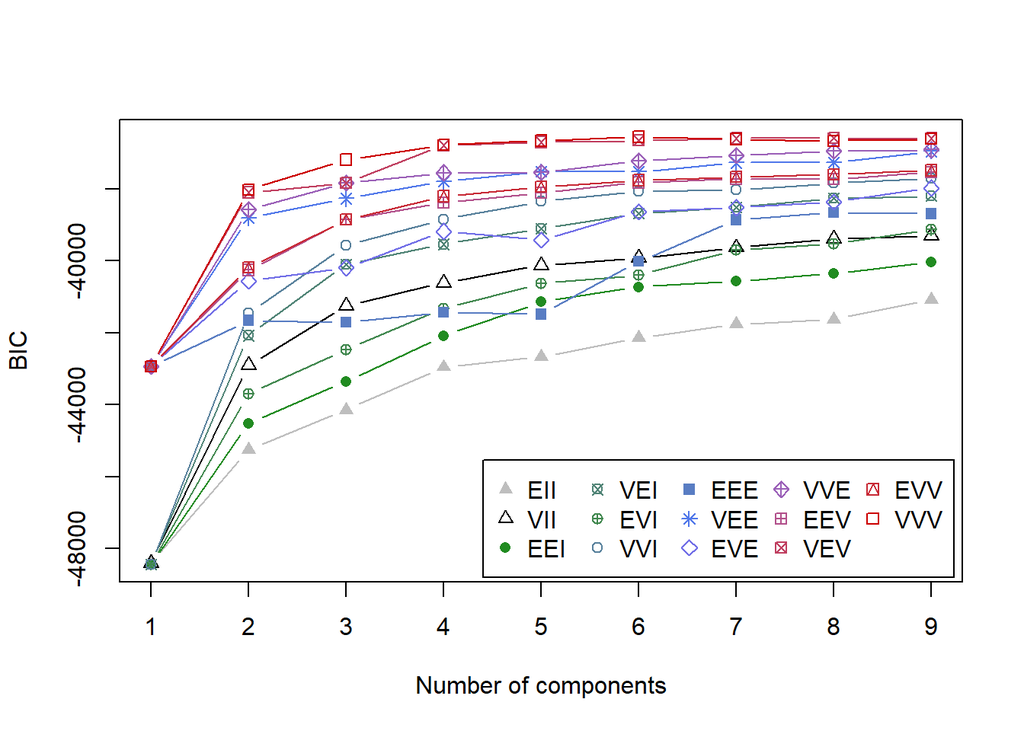

Based on the chosen model type we can display the classification chosen based on the variables used to create the clusters

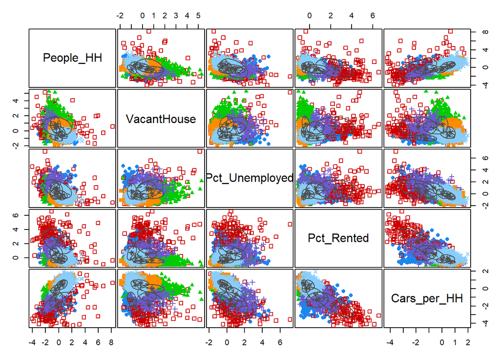

### Cluster 1

#### People_HH

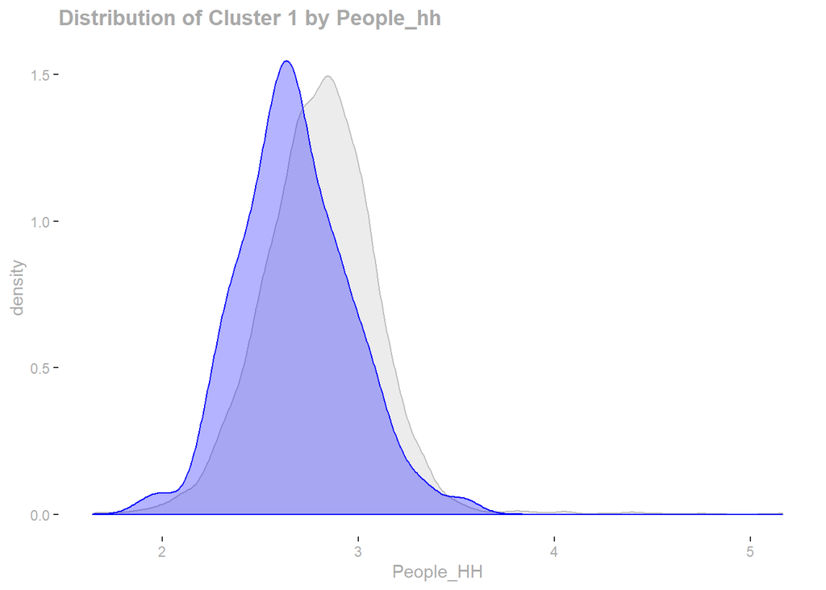

#### VacantHouse

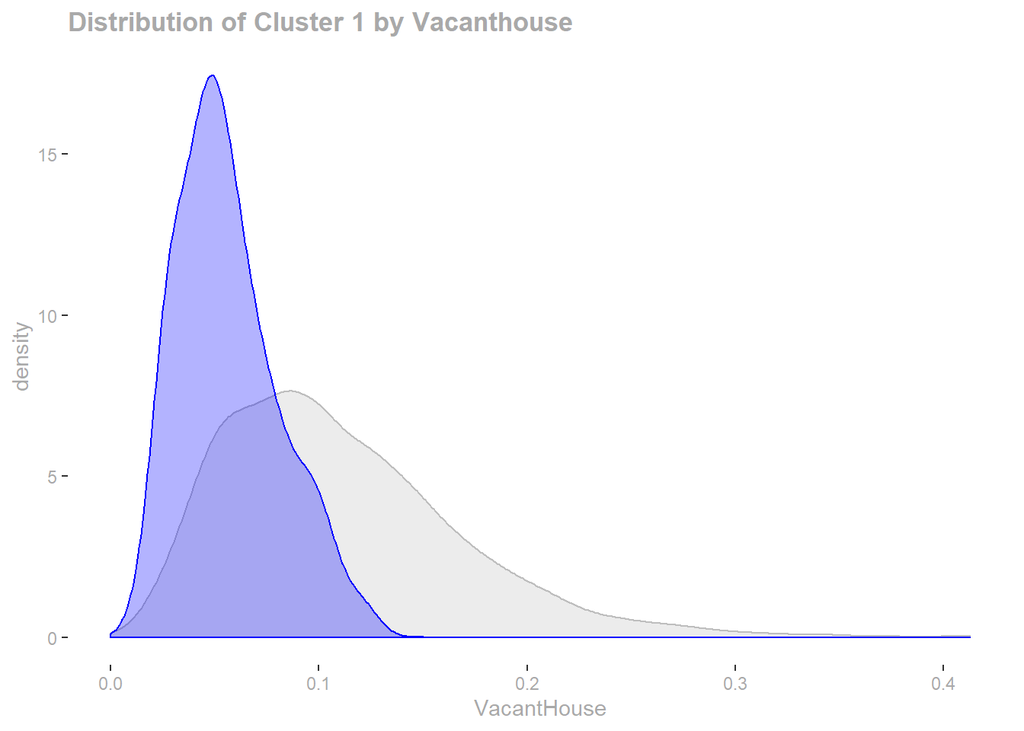

#### Pct_Unemployed

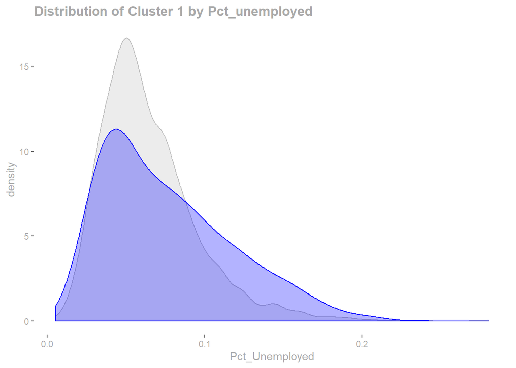

#### Pct_Rented

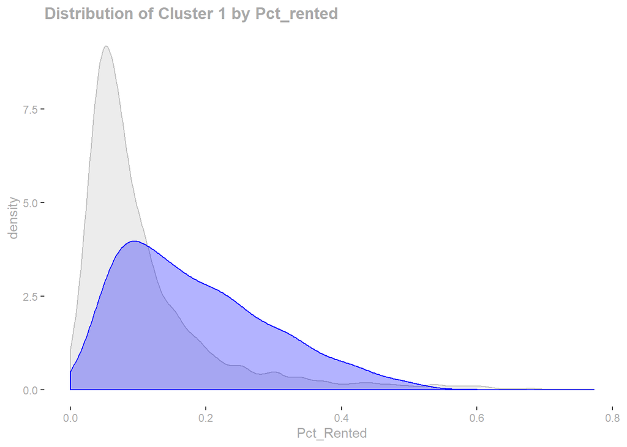

#### Cars_per_HH

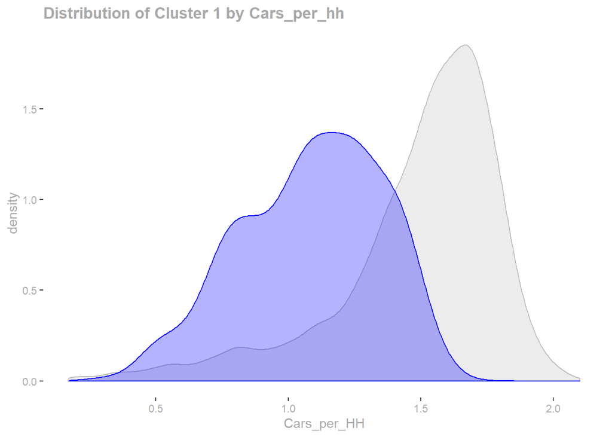

### Cluster 2

#### People_HH

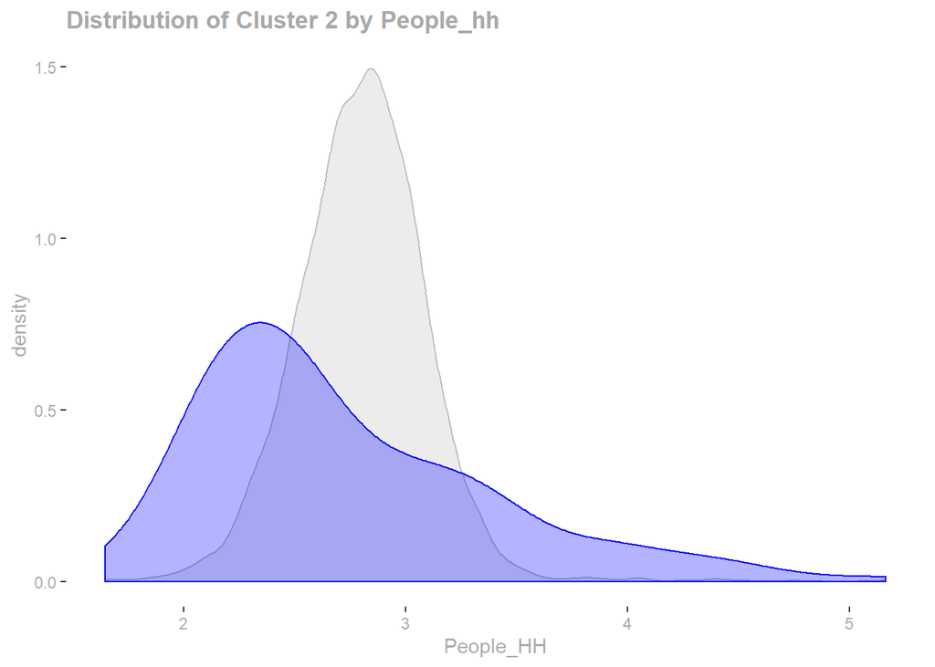

#### VacantHouse

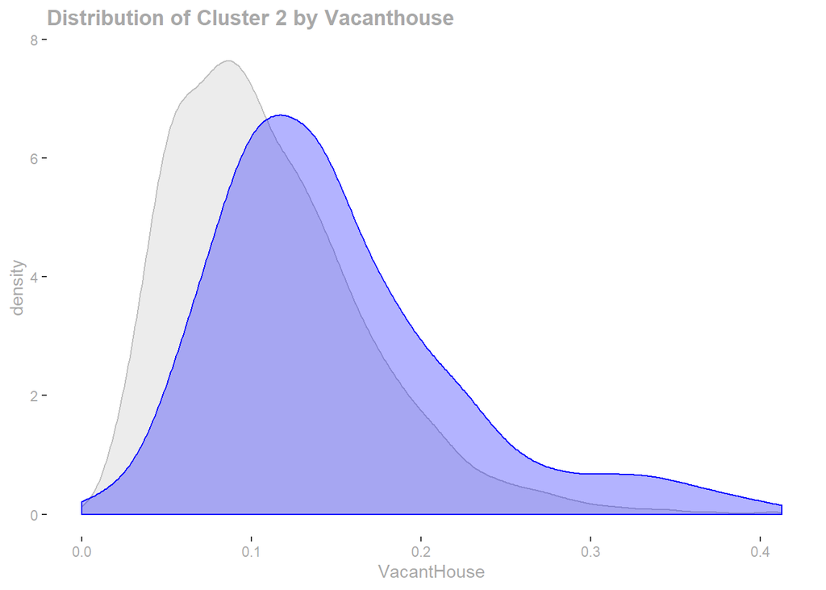

#### Pct_Unemployed

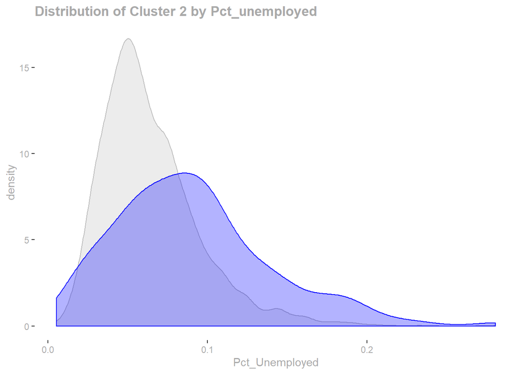

#### Pct_Rented

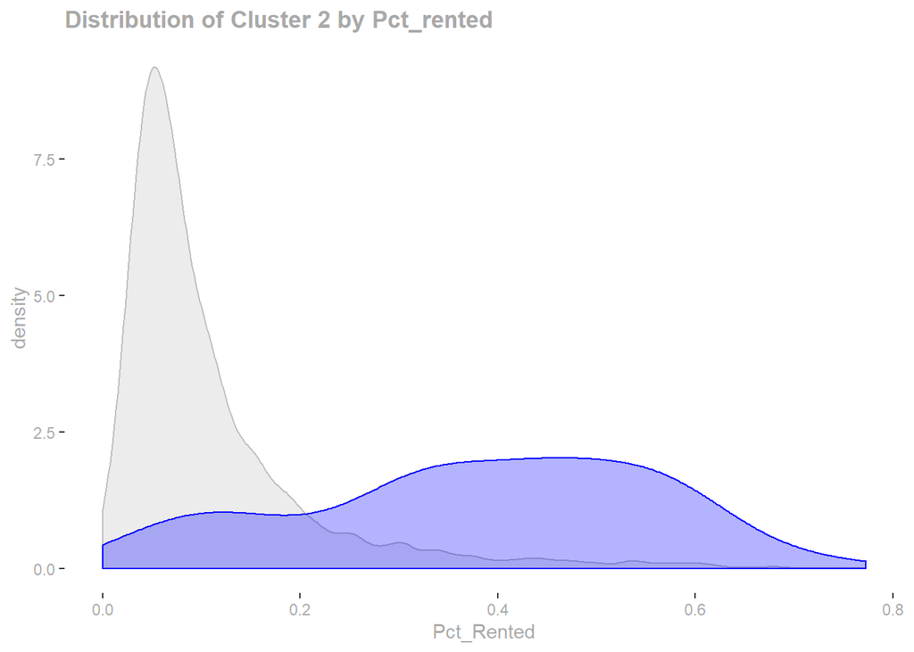

#### Cars_per_HH

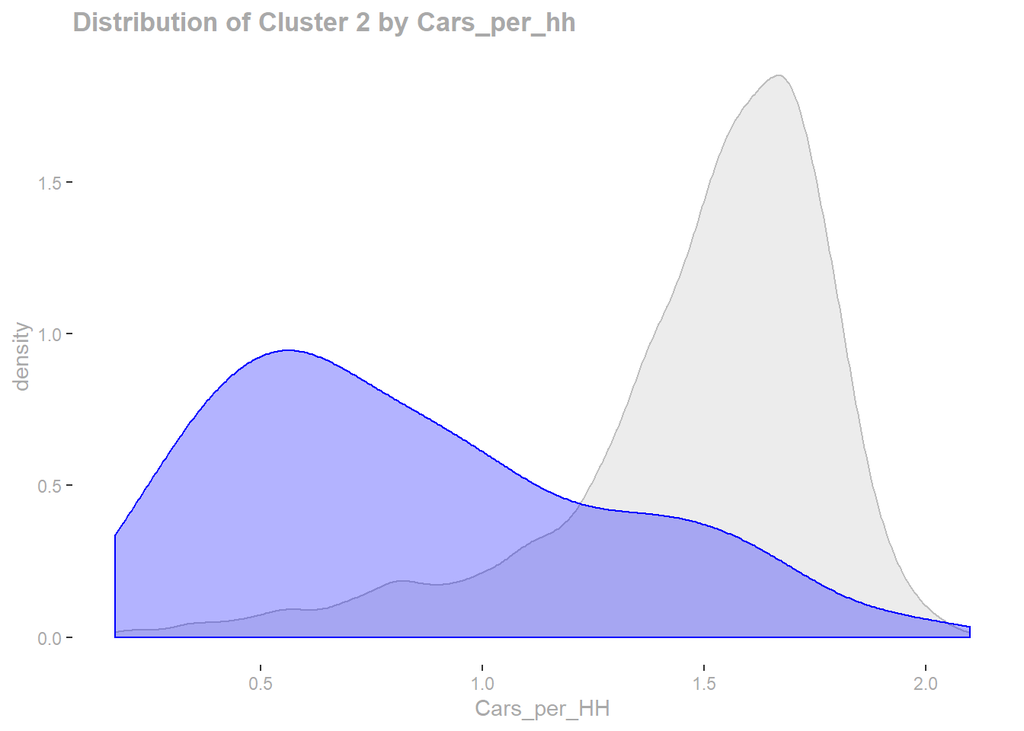

### Cluster 3

#### People_HH

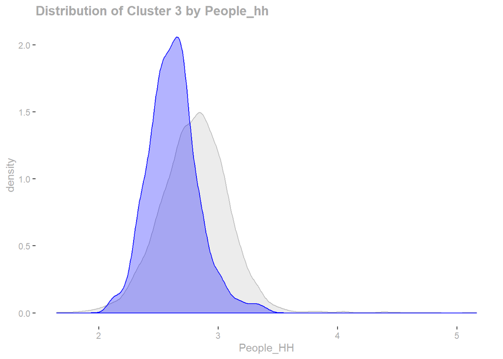

#### VacantHouse

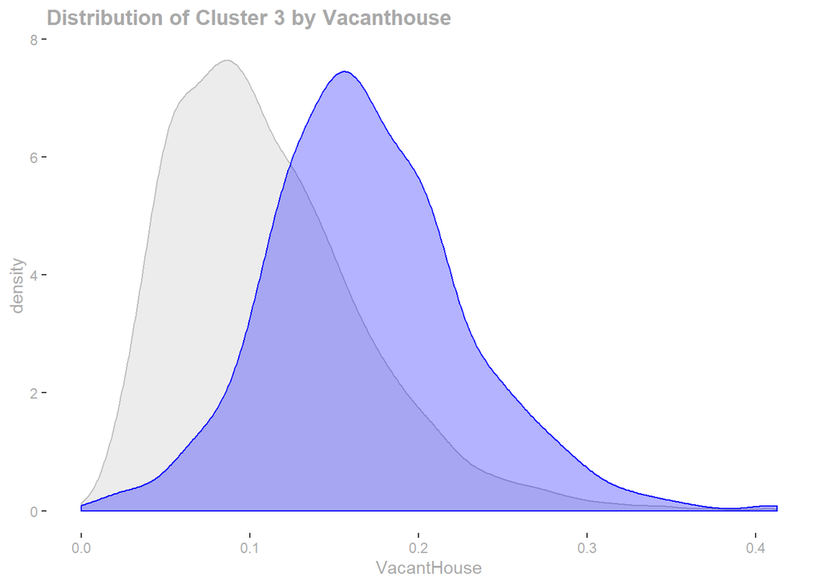

#### Pct_Unemployed

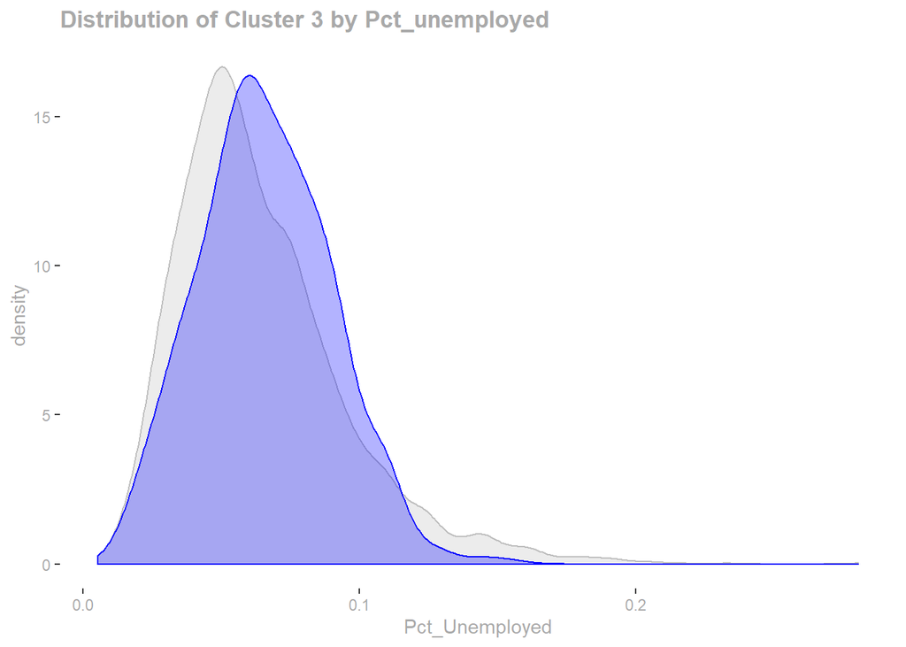

#### Pct_Rented

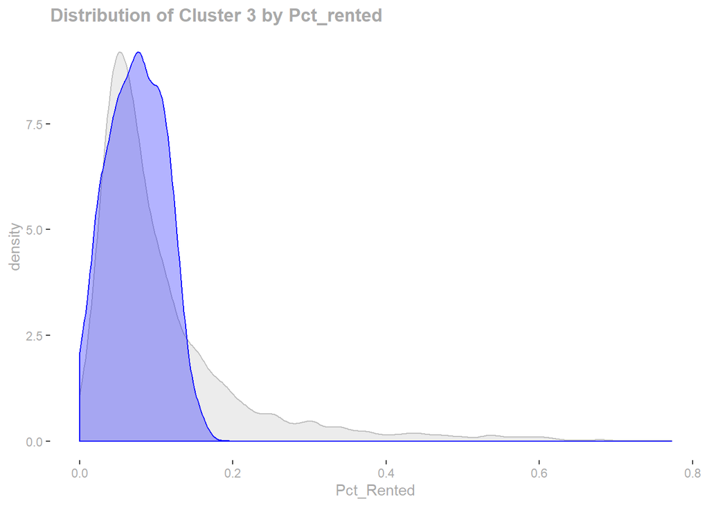

#### Cars_per_HH

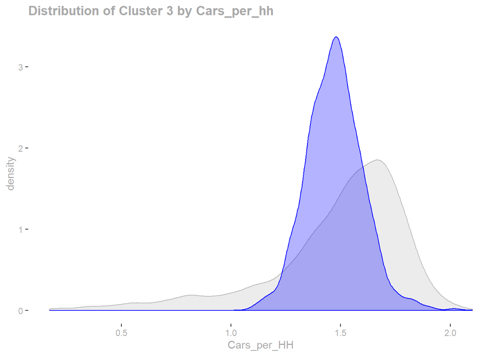

### Cluster 4

#### People_HH

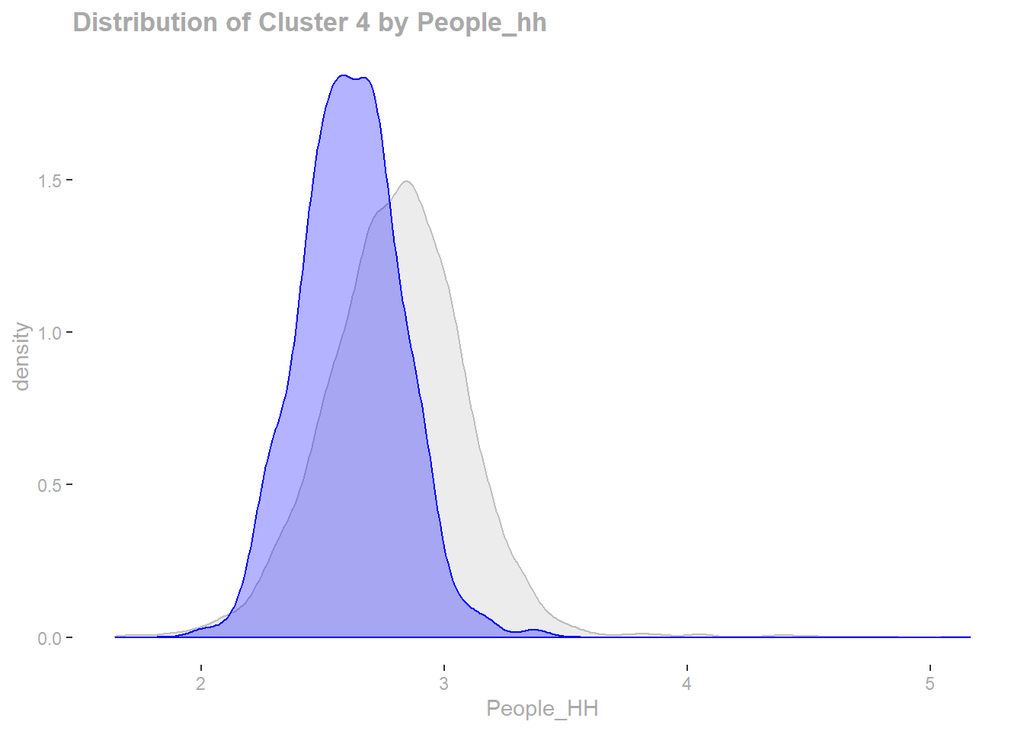

#### VacantHouse

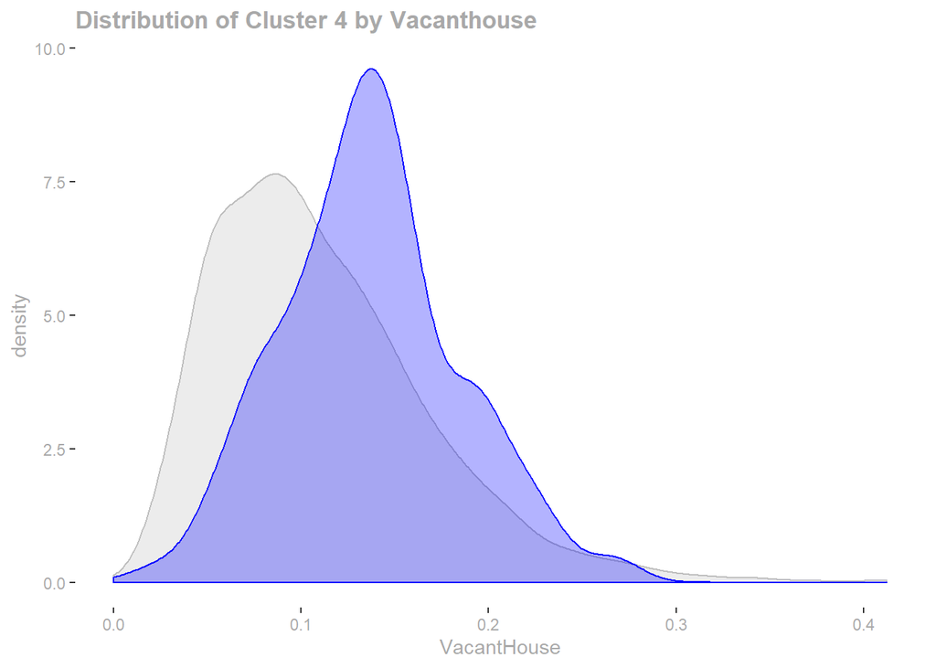

#### Pct_Unemployed

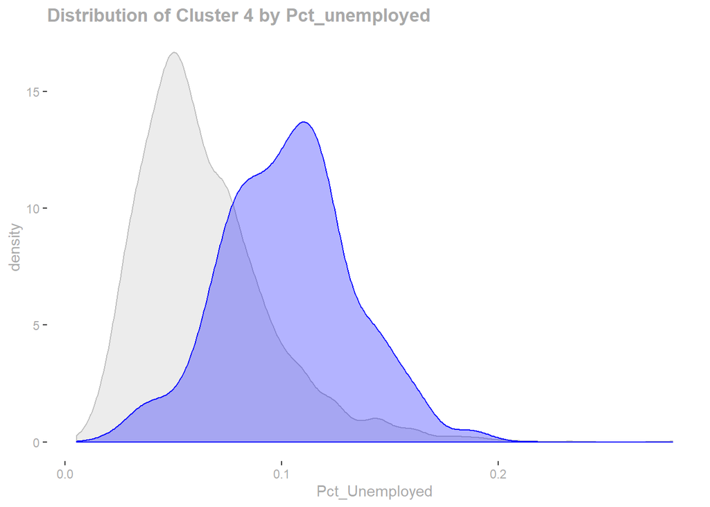

#### Pct_Rented

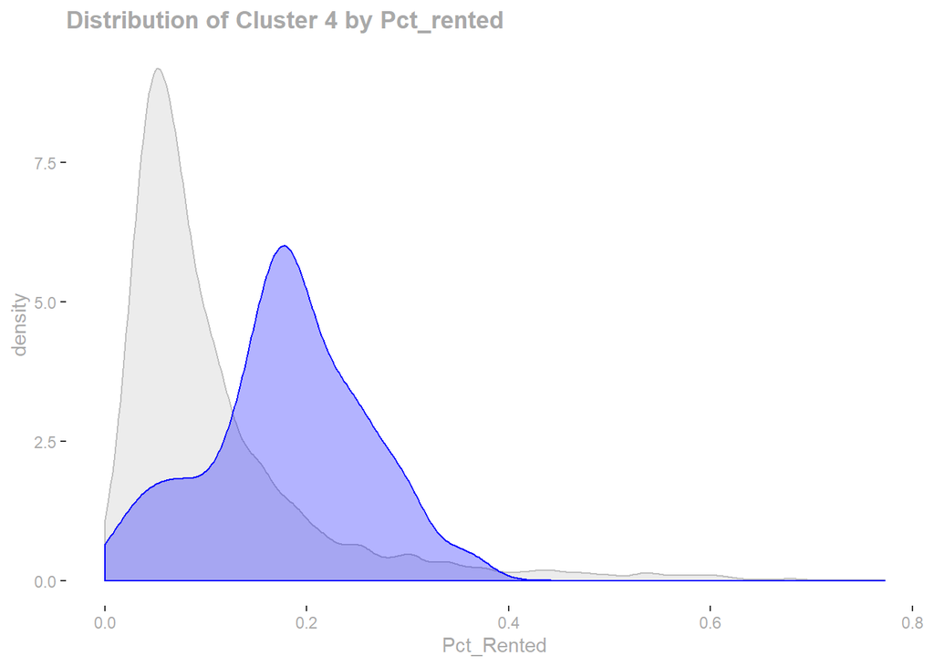

#### Cars_per_HH

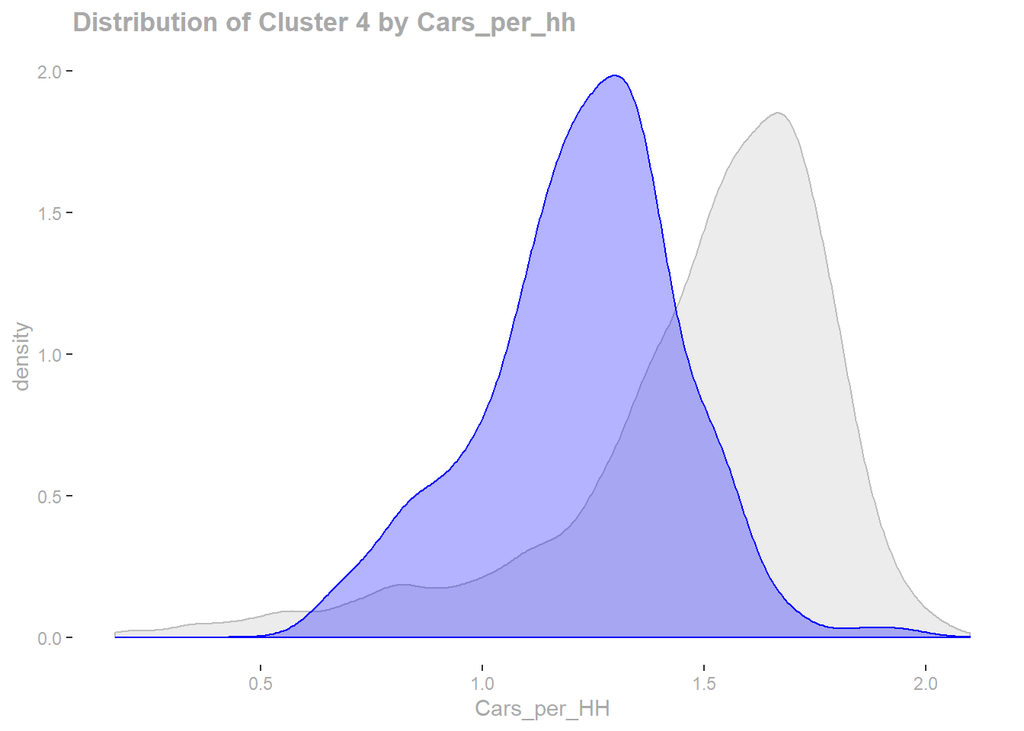